# Modelling depression with SHARE data - using survey weights

Lara Lusa and Marianne Huebner

7/12/2021

```r
source("scripts/f_readRShare.r")
load(file="out/DepressionSHAREModel.Rdata")
```

# 1 Weights in SHARE data

This document gives some examples on how to use the survey weights with SHARE data, using the study on depression as an example.

In SHARE study the sampling designs differ substantially across participating countries, from simple random sampling to multistage designs.

Both study design weights and calibrated weights are available. Study design weights take into account the selection probabilities, but their usage is discouraged, due to unit non-response and sample attrition at each follow-up.

Calibrated weights are re-weighted design weights that take the unit non-response into account and their use is advocated for inference to the target population.

Both cross-sectional (`gv_weights` modules) and longitudinal weights (`gv_weights_longitudinal` modules) are available. The target population for the longitudinal analysis is the population surviving up to the time is considered, to take sample attrition due to mortality into account. The longitudinal weights are provided for paired comparisons of adjacent waves or for the analysis of all available waves and stored in the {`gv_weights_longitudinal` modules). The modules specific to weights include also variables that indicate the strata (`stratum1`) and the primary sampling units (`psu`) (the availability differs depending on the sampling strategy of the region).

In the following we use functions from the `survey` and `srvyr` R packages for dealing with weights.

## 1.1 Study of depression using participants from single waves

Here we limit the attention to participants from single waves, retrieve the cross-sectional weights and merge the weights with the data needed for modelling probability of depression, as described for the analysis of the first interviews.

```r
source("scripts/f_readRShare.r")
load(file="out/DepressionSHAREModel.Rdata")

load(file="out/DepressionSHAREAll.Rdata")
```

The distribution of the number of interviews by wave and region is given in the table below.

```r
kable(addmargins(table(share.data$df.w$region, share.data$df.w$Wave),1), caption="Distribution of the number of interviews by wave and region")
```

Distribution of the number of interviews by wave and region

|  | Wave 1 | Wave 2 | Wave 4 | Wave 5 | Wave 6 | Wave 7 |
| --- | --- | --- | --- | --- | --- | --- |
| Northern | 4375 | 5000 | 3872 | 8163 | 7111 | 2113 |
| Western | 14380 | 14176 | 22874 | 27184 | 20263 | 4298 |
| Southern | 7113 | 8017 | 8625 | 10494 | 15935 | 4133 |
| Eastern | 0 | 4925 | 18979 | 13612 | 17903 | 1897 |
| Sum | 25868 | 32118 | 54350 | 59453 | 61212 | 12441 |

### 1.1.1 Retrieving survey weights and joining them with data

The code below retrieves the cross-sectional weights for Wave 5, and joins the data that contain the outcome variable and the covariates used in the regression models.

```r
#retrieval of weights from wave 1
share.data.weights <- f_readRShare(
  datadir = "sharedata",
  waves = 5,
  modules = "gv_weights",
  modules.wX = NULL  ,
  countries = NULL,
  variables.in.modules = NULL,
  keep.module.name.in.vars = FALSE,
  verbose = FALSE
)$df.w



# obtain only data from wave 1 from those used to develop the models that include all waves
share.data.w1 <- filter(share.data$df.w, Wave=="Wave 5")
share.data.w1 <- mutate(share.data.w1, age_int_stand = age_int -50)

# join with variable data
share.data.w1 <- left_join(share.data.weights[,c("mergeid", "dw_w5", "cciw_w5", "subsample", "stratum1", "stratum2", "psu", "ssu")], share.data.w1,  by="mergeid")

# filter out the observations with missing weights
share.data.w1  <- filter(share.data.w1, !is.na(cciw_w5))


#dropping the participants from Israel
share.data.w1  <- filter(share.data.w1, country != "Israel")

#dropping unused levels
share.data.w1 <- droplevels(share.data.w1)
```

### 1.1.2 Estimation of weighted prevalence of depression

Here we estimate the weighted proportion of participants with depression by region, using the calibrated weights. We use `stratum1` as the stratification variable and `psu` as the primary sampling unit identifier. For the countries that did not use stratification (`stratum1` not specified) we defined a single stratum), for those that did not use clustering (`psu` not specified) we used a different `psu` value for each participant. The table below shows the classification of countries based on the sampling design.

```r
kable(share.data.w1 %>% group_by (country) %>% summarise(Stratification = any(stratum1!=""), Clustering = any(psu!="")) %>% arrange(Stratification, Clustering), caption = "Classification of countries in Wave 5 by use of stratification and clustering")
```

Classification of countries in Wave 5 by use of stratification and clustering

| country | Stratification | Clustering |
| --- | --- | --- |
| Denmark | FALSE | FALSE |
| Netherlands | FALSE | TRUE |
| Germany | FALSE | TRUE |
| Luxembourg | TRUE | FALSE |
| Switzerland | TRUE | FALSE |
| Estonia | TRUE | FALSE |
| Sweden | TRUE | TRUE |
| Belgium | TRUE | TRUE |
| France | TRUE | TRUE |
| Austria | TRUE | TRUE |
| Spain | TRUE | TRUE |
| Italy | TRUE | TRUE |
| Czech Republic | TRUE | TRUE |
| Slovenia | TRUE | TRUE |

```r
# assign weights equal to 1 to all participants in an additional variable to obtain unweighted estimates
share.data.w1$wAll1 <- 1


# setting to missing the strata and psu values that are empty
share.data.w1$stratum1[share.data.w1$stratum1==""] <- NA
share.data.w1$psu[share.data.w1$psu==""] <- NA
# number of missing psu
num.na.psu <- sum(is.na(share.data.w1$psu))
share.data.w1$psu <- as.numeric(share.data.w1$psu)

# using constant values for strata within country, all different values of psu for countries that did not have them in the design
share.data.w1$stratum1[is.na(share.data.w1$stratum1)] <- paste(share.data.w1$country[is.na(share.data.w1$stratum1)], "fake stratum")
share.data.w1$psu[is.na(share.data.w1$psu)] <- c((10^9+1) :  (10^9+num.na.psu))


# specify the sampling design
dstrat <- survey::svydesign(id=~psu,strata=~stratum1, weights=~ cciw_w5,
data = share.data.w1, nest=TRUE)

# id=∼psu specifies sampling at primary sampling unit.
# stratum1 is a factor variable for stratum used for sampling, usually geographical units
# share.data.w1 is the data frame with all the data.
# cciw_w5 contains calibrated sampling weights

# remove the participants not used in the analysis - removed because of missing data or exclusion criteria
dstrat <- subset(dstrat, !is.na(eurodcat_imp))

#to take into account the problem related to strata with a single psu
options(survey.lonely.psu="adjust")



# Create summary data, weighted
lr_gen_w1_d <- share.data.w1  %>%
  as_survey_design(weights = c(cciw_w5), ids = psu, strata = stratum1, nest= TRUE) %>% subset(!is.na(eurodcat_imp)) %>%
  group_by(region, gender) %>%
  summarize(n = survey_mean(eurodcat_imp, na.rm = T, vartype = "ci"))


# Create summary data, weighted
lr_gen_un <- share.data.w1  %>%
  as_survey_design(weights = c(wAll1)) %>% subset(!is.na(eurodcat_imp)) %>%
  group_by(region, gender) %>%
  summarize(n = survey_mean(eurodcat_imp, na.rm = T, vartype = "ci"))


# Create summary data, weighted but without design information
lr_gen_w1 <- share.data.w1  %>%
  as_survey_design(weights = c(cciw_w5)) %>% subset(!is.na(eurodcat_imp)) %>%
  group_by(region, gender) %>%
  summarize(n = survey_mean(eurodcat_imp, na.rm = T, vartype = "ci"))



df <- cbind.data.frame(lr_gen_un, lr_gen_w1_d[, c("n", "n_low", "n_upp")], lr_gen_w1[, c("n", "n_low", "n_upp")] )
dimnames(df)[[2]] <- c("Region", "Gender", "Depression prob - UW", "CI LL - UW", "CI UL - UW",
                       "Depression prob - W,D", "CI LL - W,D", "CI UL - W,D",
                       "Depression prob - W", "CI LL - W", "CI UL - W"
                        )

tab.w5 <- df

kable(df, digits=2, caption="Prevalence of depression and 95% CI stratified by gender and region; UW: unweighted, W: weighted using calibration weights, D: using sampling design.")
```

Prevalence of depression and 95% CI stratified by gender and region; UW: unweighted, W: weighted using calibration weights, D: using sampling design.

| Region | Gender | Depression prob - UW | CI LL - UW | CI UL - UW | Depression prob - W,D | CI LL - W,D | CI UL - W,D | Depression prob - W | CI LL - W | CI UL - W |
| --- | --- | --- | --- | --- | --- | --- | --- | --- | --- | --- |
| Northern | Male | 0.12 | 0.11 | 0.13 | 0.14 | 0.12 | 0.15 | 0.14 | 0.12 | 0.15 |
| Northern | Female | 0.23 | 0.21 | 0.24 | 0.24 | 0.23 | 0.26 | 0.24 | 0.23 | 0.26 |
| Western | Male | 0.18 | 0.17 | 0.18 | 0.20 | 0.18 | 0.21 | 0.20 | 0.18 | 0.21 |
| Western | Female | 0.30 | 0.29 | 0.30 | 0.33 | 0.32 | 0.34 | 0.33 | 0.32 | 0.34 |
| Southern | Male | 0.21 | 0.20 | 0.22 | 0.21 | 0.19 | 0.23 | 0.21 | 0.19 | 0.22 |
| Southern | Female | 0.40 | 0.38 | 0.41 | 0.43 | 0.40 | 0.45 | 0.43 | 0.41 | 0.45 |
| Eastern | Male | 0.22 | 0.21 | 0.23 | 0.19 | 0.17 | 0.22 | 0.19 | 0.17 | 0.22 |
| Eastern | Female | 0.35 | 0.34 | 0.36 | 0.33 | 0.30 | 0.35 | 0.33 | 0.31 | 0.35 |

```r
svymean(~eurodcat_imp, dstrat, na.rm=TRUE)
```

```
##                 mean     SE
## eurodcat_imp 0.28031 0.0042
```

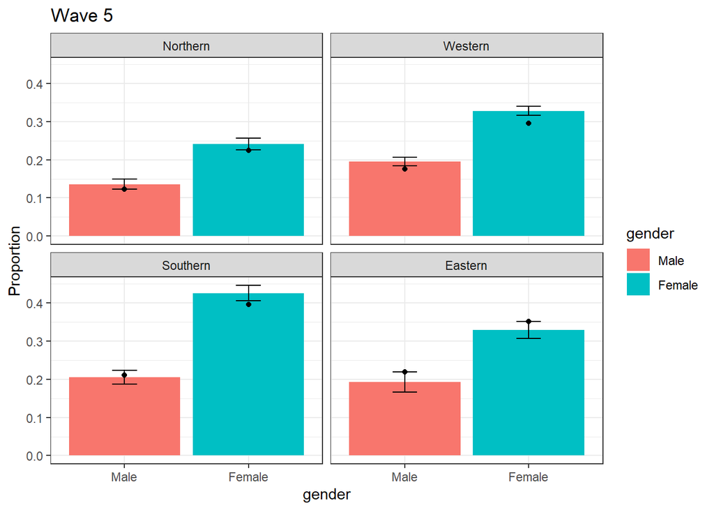

```r
#kable(cbind.data.frame(lr_gen_un, lr_gen_w1[, c("n", "n_low", "n_upp")]), digits=2, caption="Unweighted (left) and weighted (right) prevalence of depression, #stratified by gender and region.")


# Plot proportion with depression
prev.w5 <- ggplot(lr_gen_w1, aes(x = gender, y = n)) +
  geom_bar(aes(fill = gender), stat = "identity") +
  geom_errorbar(aes(ymin = n_low, max = n_upp), width = 0.2) +
  facet_wrap(~region) +
  theme_bw() + geom_point(data=lr_gen_un, aes(gender, y=n)) + ggtitle("Wave 5") + labs(y="Proportion") #adding unweighted data

prev.w5
```

```r
# Plot it
#ggplot(lr_gen, aes(x = gender, y = n)) +
#  geom_bar(aes(fill = gender), stat = "identity") +
#  geom_errorbar(aes(ymin = n_low, max = n_upp), width = 0.2) +
#  facet_wrap(~region) +
#  theme_bw()



#overall weighted estimate
#share.data.w1  %>%
#     as_survey_design(weights = c(cciw_w5)) %>% subset(!is.na(eurodcat_imp)) %$% svymean(~eurodcat_imp, .)

#unweighted estimate
prop.test(table(share.data.w1$eurodcat_imp==0))
```

```
##
##  1-sample proportions test with continuity correction
##
## data:  table(share.data.w1$eurodcat_imp == 0), null probability 0.5
## X-squared = 13863, df = 1, p-value < 2.2e-16
## alternative hypothesis: true p is not equal to 0.5
## 95 percent confidence interval:
##  0.2529968 0.2600935
## sample estimates:
##         p
## 0.2565291
```

The weighted estimated proportion of participants with depression are slightly higher than those obtained using unweighted data, except for the Estern region, where they were lower.

Distribution of the participants, with complete (TRUE) or missing outcome variable.

```r
addmargins(table(share.data.w1$region, !is.na(share.data.w1$eurodcat_imp)))
```

```
##
##            FALSE  TRUE   Sum
##   Northern    51  8089  8140
##   Western    304 26826 27130
##   Southern   215 10252 10467
##   Eastern    296 13302 13598
##   Sum        866 58469 59335
```

### 1.1.3 Regression analysis

Here we show how to fit the weighted logistic regression models with the `svyglm` function, using the calibrated weights and taking the sampling design into account.

#### 1.1.3.1 Unadjusted models - weighted models and comparsion with unweighted

```r
my.mod <- lm(gender ~ rcs(age_int_stand) ,
                                             data=share.data.w1[, ], family="binomial",  x=TRUE, y=TRUE)

#save the spline terms in the complete data set for further use
share.data.w1 <- share.data.w1 %>% mutate(age1 = my.mod$x[,2],
                                                                    age2 = my.mod$x[,3],
                                                                    age3 = my.mod$x[,4],
                                                                    age4 = my.mod$x[,5])


my.mod <- glm(eurodcat_imp ~ rcs(age_int_stand) + gender + region +
                       rcs(age_int_stand):region + rcs(age_int_stand):gender + gender:region ,
                                             data=share.data.w1, family="binomial",  x=TRUE, y=TRUE)


# retrieve the location of knots used and assign them to Knots variable
Knots <- Hmisc::rcspline.eval(x = share.data.w1$age_int_stand, nk = 5, knots.only = TRUE)

#reproduces the spline values for age, expands for each integer value from 50 to 90
age = rcspline.eval(c(50:90)-50, knots=Knots)
age <- cbind.data.frame(age1=c(50:90)-50, age )
dimnames(age)[[2]] <- c("age1", "age2", "age3", "age4")






if(!is.null(my.mod$na.action)){
my.mod2 <- glm(eurodcat_imp ~ age1 + age2 + age3 + age4 + gender + region +
                      age1:region + age2:region + age3:region + age4:region +
                       age1:gender + age2:gender + age3:gender + age4:gender +
                       gender:region ,
                        data=share.data.w1[-my.mod$na.action,], family="binomial",  x=TRUE, y=TRUE)} else {
 my.mod2 <- glm(eurodcat_imp ~ age1 + age2 + age3 + age4 + gender + region +
                      age1:region + age2:region + age3:region + age4:region +
                       age1:gender + age2:gender + age3:gender + age4:gender +
                       gender:region ,
                        data=share.data.w1, family="binomial",  x=TRUE, y=TRUE)
}





#derive the data.frame containing the levels of the covariatee, where the probabilities of depression estimated by the model will be derived
data.grid <- expand.grid(age1=age[,1], gender=levels(share.data.w1$gender), region=levels(share.data.w1$region))
data.grid <- left_join(data.grid, age, by="age1" )

#data.grid <- filter(data.grid, is.element(region, c("Austria", "Spain", "Italy", "France", "Belgium", "Israel")))
data.grid.region <- data.grid


#defining also data grid for countries
data.grid.region <- expand.grid(age1=age[,1], gender=levels(share.data.w1$gender), region=levels(share.data.w1$region))
data.grid.region <- left_join(data.grid.region, age, by="age1" )




#derive the predicted probabilities
my.pred <- predict(my.mod2, newdata=data.grid, se.fit = TRUE, type="response")

#join the levels of the covariates and the predicted probabilities
my.pred.all <- cbind.data.frame(data.grid, my.pred)

#saving the estimates from the 2-way models
pred.age_unadjusted_region_rcs <- my.pred.all
```

```r
ggplot(my.pred.all, aes(age1+50, fit, color=gender)) + geom_line() + facet_wrap(region~., ncol=5) + labs(x="Age", y="Estimated probability of depression") + scale_color_manual(values=c("#4699dd","#ff3db7" )) + ggtitle("Unadjusted - (gender, region, rcs(age))") +
  geom_ribbon(aes(ymin = fit - 1.96*se.fit, ymax = fit + 1.96*se.fit), alpha = 0.2, linetype=0) +  theme_bw()


#my.pred.all %>% left_join(select(share.data.w1, starts_with("region")), by="region") %>% ggplot(aes(age1, fit, #color=gender))+ geom_point() + facet_grid(.~regionGroup) + labs(x="Age", y="Estimated probability of depression") + #scale_color_manual(values=c("#4699dd","#ff3db7" ))


#anova(my.mod, test="Chi")
```

[output not shown]

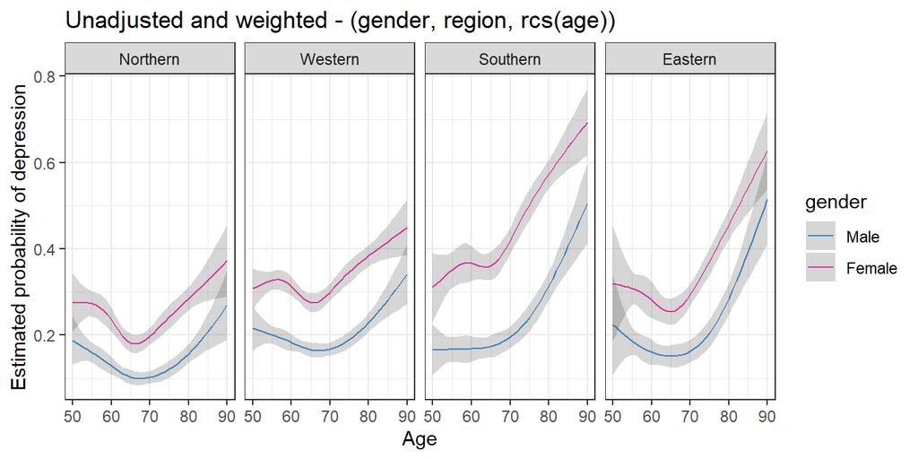

```r
# specify the sampling design
dstrat <- survey::svydesign(id=~psu,strata=~stratum1, weights=~ cciw_w5,
data = share.data.w1, nest=TRUE)


# remove the participants not used in the analysis - removed because of missing data or exclusion criteria
dstrat <- subset(dstrat, !is.na(eurodcat_imp))

 my.mod.w <- svyglm(eurodcat_imp ~ age1 + age2 + age3 + age4 + gender + region +
                      age1:region + age2:region + age3:region + age4:region +
                       age1:gender + age2:gender + age3:gender + age4:gender +
                       gender:region ,
                        design=dstrat, family="binomial",  x=TRUE, y=TRUE)




#derive the predicted probabilities
my.pred <- predict(my.mod.w, newdata=data.grid, se.fit = TRUE, type="response")
#join the levels of the covariates and the predicted probabilities
my.pred.all <- cbind.data.frame(data.grid, my.pred)

my.pred.all <- pred.age_unadjusted_region_rcs_w<- rename(my.pred.all, fit=response, se.fit = SE)
pred.age_unadjusted_region_rcs_w <- mutate(pred.age_unadjusted_region_rcs_w, residual.scale = 1)

pred.age_all <- rbind.data.frame(pred.age_unadjusted_region_rcs,pred.age_unadjusted_region_rcs_w)
pred.age_all <- mutate(pred.age_all, model=c(rep("Unadjusted \n rcs", nrow(pred.age_unadjusted_region_rcs)), rep("Unadjusted weighted \n rcs", nrow(pred.age_unadjusted_region_rcs))))

#saving the estimates from the 2-way models
pred.age_unadjusted_region_rcs <- my.pred.all




ggplot(my.pred.all, aes(age1+50, fit, color=gender)) + geom_line() + facet_wrap(region~., ncol=5) + labs(x="Age", y="Estimated probability of depression") + scale_color_manual(values=c("#4699dd","#ff3db7" )) + ggtitle("Unadjusted and weighted - (gender, region, rcs(age))") +
  geom_ribbon(aes(ymin = fit - 1.96*se.fit, ymax = fit + 1.96*se.fit), alpha = 0.2, linetype=0) +  theme_bw()
```

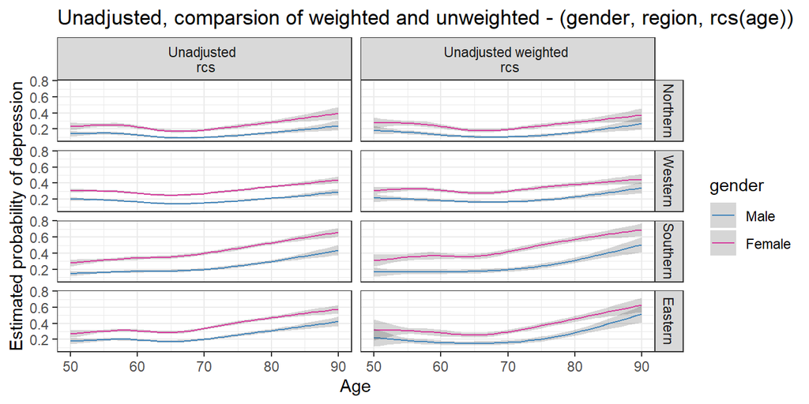

```r
#my.pred.all %>% left_join(select(share.data.w1, starts_with("region")), by="region") %>% ggplot(aes(age1, fit, #color=gender))+ geom_point() + facet_grid(.~regionGroup) + labs(x="Age", y="Estimated probability of depression") + #scale_color_manual(values=c("#4699dd","#ff3db7" ))


#anova(my.mod.w, test="Chi")



ggplot(pred.age_all, aes(age1+50, fit, color=gender)) + geom_line() + facet_grid(region~model) + labs(x="Age", y="Estimated probability of depression") + scale_color_manual(values=c("#4699dd","#ff3db7" )) + ggtitle("Unadjusted, comparsion of weighted and unweighted - (gender, region, rcs(age))") +
  geom_ribbon(aes(ymin = fit - 1.96*se.fit, ymax = fit + 1.96*se.fit), alpha = 0.2, linetype=0) +  theme_bw()
```

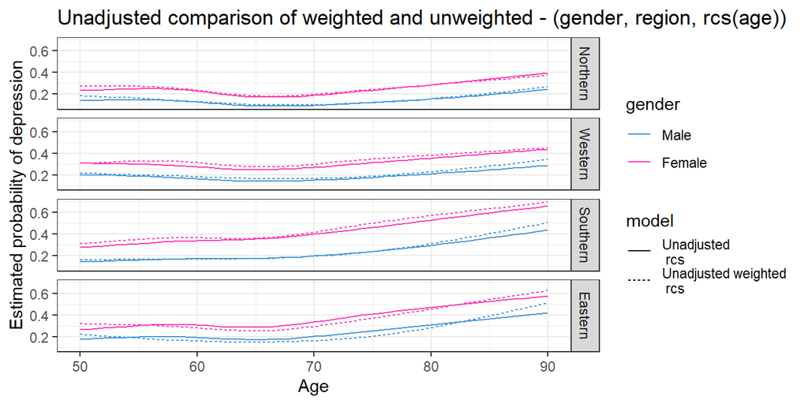

```r
ggplot(pred.age_all, aes(age1+50, fit, color=gender)) + geom_line(aes(linetype=model)) + facet_grid(region~.) + labs(x="Age", y="Estimated probability of depression") + scale_color_manual(values=c("#4699dd","#ff3db7" )) + ggtitle("Unadjusted comparison of weighted and unweighted - (gender, region, rcs(age))") +
 # geom_ribbon(aes(ymin = fit - 1.96*se.fit, ymax = fit + 1.96*se.fit), alpha = 0.2, linetype=0) +
  theme_bw()
```

In wave 5 using weights increased the variability of the estimates, but not dramatically. The shape of the estimated association between age and probability of depression were very similar in the two analyses. The estimated weighted probabilities were slightly larger in Southern region.`

#### 1.1.3.2 Adjusted models - weighted models and comparsion with unweighted

```r
my.mod2  <- glm(
  eurodcat_imp ~
    age1 + age2 + age3 + age4 + gender + region +
    bmi_imp + education_imp + cusmoke_imp + dis_chronic_pres +
    pa_vig + living_arrangement +
    age1:region + age2:region + age3:region + age4:region +
    age1:gender + age2:gender + age3:gender + age4:gender +
    gender:region,
  data = share.data.w1,
  family = "binomial",
  x = TRUE,
  y = TRUE
)



my.mod1  <- glm(
  eurodcat_imp ~
    rcspline.eval(age_int_stand, knots=Knots, inclx = TRUE) + gender + region +
    bmi_imp + education_imp + cusmoke_imp + dis_chronic_pres +
    pa_vig + living_arrangement +
     rcspline.eval(age_int_stand, knots=Knots, inclx = TRUE):region +
     rcspline.eval(age_int_stand, knots=Knots, inclx = TRUE):gender +
    gender:region,
  data = share.data.w1,
  family = "binomial",
  x = TRUE,
  y = TRUE
)



data.grid.adj <- expand.grid(age1=unique(share.data.w1$age1), gender=levels(share.data.w1$gender), region=levels(share.data.w1$region),
                         #overall mean
                         #bmi_10 = mean(share.data.w1$bmi_imp, na.rm=TRUE),

                      education_imp ="Low", cusmoke_imp="No",  dis_chronic_pres="0",
                        pa_vig = "Hardly ever, or never" ,  living_arrangement="Living with partner"
                         )


#using median bmi, separate evaluation by gender

data.grid.adj <- left_join(data.grid.adj,
          share.data.w1 %>% group_by(gender) %>%
            #rename(age1 = age_int_stand) %>%
            summarise(bmi_imp=median(bmi_imp, na.rm=TRUE)),
           by=c("gender"))

data.grid.adj <- left_join(data.grid.adj, age, by="age1")
data.grid.adj.region <- data.grid.adj



#defining also data grid for countries
data.grid.adj.region <- expand.grid(age1=unique(share.data.w1$age1), gender=levels(share.data.w1$gender), region=levels(share.data.w1$region),
                         #overall mean
                         #bmi_10 = mean(share.data.w1$bmi_imp, na.rm=TRUE),

                      education_imp ="Low", cusmoke_imp="No",  dis_chronic_pres="0",
                        pa_vig = "Hardly ever, or never" ,  living_arrangement="Living with partner"
                         )
data.grid.adj.region <- left_join(data.grid.adj.region,
          share.data.w1 %>% group_by(gender) %>%
            #rename(age1 = age_int_stand) %>%
            summarise(bmi_imp=median(bmi_imp, na.rm=TRUE)),
           by=c("gender"))

data.grid.adj.region <- left_join(data.grid.adj.region, age, by="age1")


#derive the predicted probabilities
my.pred <- predict(my.mod2, newdata=data.grid.adj, se.fit = TRUE, type="response")

#join the levels of the covariates and the predicted probabilities
my.pred.all <- cbind.data.frame(data.grid.adj, my.pred)

#saving the estimates from the 2-way models
pred.age_adjusted_region_rcs <- my.pred.all


pred.age_adjusted_region_rcs <- mutate( pred.age_adjusted_region_rcs ,  "education_imp"=NA,      "cusmoke_imp"=NA  ,      "dis_chronic_pres"=NA  ,  "pa_vig" = NA,  "living_arrangement" = NA,  "bmi_imp" = NA,  "age2" = NA        ,       "age3" = NA ,              "age4" = NA    )
pred.age_adjusted_region_rcs<- mutate(pred.age_adjusted_region_rcs, model="Adjusted \n rcs")


pred.age_all <- mutate(pred.age_all,
                     "education_imp"=NA,      "cusmoke_imp"=NA  ,      "dis_chronic_pres"=NA  ,  "pa_vig" = NA,  "living_arrangement" = NA,  "bmi_imp" = NA )



pred.age_all <- rbind.data.frame(pred.age_all, pred.age_adjusted_region_rcs)
```

```r
ggplot(my.pred.all, aes(age1+50, fit, color=gender)) + geom_line() + facet_wrap(region~., ncol=5) + labs(x="Age", y="Estimated probability of depression") + scale_color_manual(values=c("#4699dd","#ff3db7" )) + ggtitle("Adjusted estimates (gender, region, rcs(age))") +
  geom_ribbon(aes(ymin = fit - 1.96*se.fit, ymax = fit + 1.96*se.fit), alpha = 0.2, linetype=0) +  theme_bw()


#anova(my.mod1, test="Chi")
```

[output not shown]

```r
#to display all the coefficients
#get.OR2(my.mod1)


#kable(get.OR2(my.mod1)[10:20,], digits=2, caption = "Estimated OR from the adjusted rcs model")
#kable(get.OR2(my.mod1)[10:20,], digits=2, caption = "Estimated OR from the adjusted rcs model",     format = "latex")


OR.uw <- get.OR2(my.mod1)[10:20,]
```

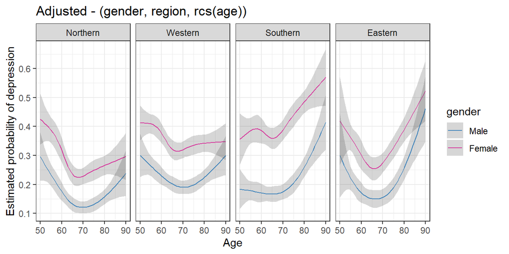

```r
#dstrat <- svydesign(id=~psu,strata=~stratum1, weights=~ cciw_w5,
#data=share.data.w1, nest=TRUE)


 my.mod.w <- svyglm(eurodcat_imp ~
    age1 + age2 + age3 + age4 + gender + region +
    bmi_imp + education_imp + cusmoke_imp + dis_chronic_pres +
    pa_vig + living_arrangement +
    age1:region + age2:region + age3:region + age4:region +
    age1:gender + age2:gender + age3:gender + age4:gender +
    gender:region,
                        design=dstrat, family="binomial",  x=TRUE, y=TRUE)




#derive the predicted probabilities
my.pred <- predict(my.mod.w, newdata=data.grid.adj.region, se.fit = TRUE, type="response")
#join the levels of the covariates and the predicted probabilities
my.pred.all <- cbind.data.frame(data.grid.adj.region, my.pred)

my.pred.all <- pred.age_unadjusted_region_rcs_w<- rename(my.pred.all, fit=response, se.fit = SE)
pred.age_adjusted_region_rcs_w <- mutate(pred.age_unadjusted_region_rcs_w, residual.scale = 1, model = "Adjusted weighted \n rcs")

pred.age_all <- rbind.data.frame(pred.age_all, pred.age_adjusted_region_rcs_w)

#saving the estimates from the 2-way models
pred.age_adjusted_region_rcs_w <- my.pred.all

ggplot(my.pred.all, aes(age1+50, fit, color=gender)) + geom_line() + facet_wrap(region~., ncol=5) + labs(x="Age", y="Estimated probability of depression") + scale_color_manual(values=c("#4699dd","#ff3db7" )) + ggtitle("Adjusted - (gender, region, rcs(age))") +
  geom_ribbon(aes(ymin = fit - 1.96*se.fit, ymax = fit + 1.96*se.fit), alpha = 0.2, linetype=0) +  theme_bw()
```

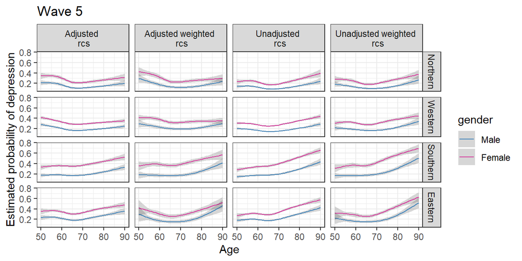

```r
#my.pred.all %>% left_join(select(share.data.w1, starts_with("region")), by="region") %>% ggplot(aes(age1, fit, #color=gender))+ geom_point() + facet_grid(.~regionGroup) + labs(x="Age", y="Estimated probability of depression") + #scale_color_manual(values=c("#4699dd","#ff3db7" ))


#anova(my.mod.w, test="Chi")

pred.age_all$modelAdjUnadj <- pred.age_all$modelWeightedUnw <- pred.age_all$model

level_key <- c(`Unadjusted \n rcs` = "Unadjusted", `Unadjusted weighted \n rcs` = "Unadjusted",
               `Adjusted \n rcs` = "Adjusted", `Adjusted weighted \n rcs` = "Adjusted"
                 )

pred.age_all$modelAdjUnadj <- recode_factor(pred.age_all$modelAdjUnadj, !!!level_key)


level_key <- c(`Unadjusted \n rcs` = "Unweighted", `Unadjusted weighted \n rcs` = "Weighted",
               `Adjusted \n rcs` = "Unweighted", `Adjusted weighted \n rcs` = "Weighted"
                 )

pred.age_all$modelWeightedUnw <- recode_factor(pred.age_all$modelWeightedUnw, !!!level_key)



modCI.w5 <- ggplot(pred.age_all, aes(age1+50, fit, color=gender)) + geom_line() + facet_grid(region~model) + labs(x="Age", y="Estimated probability of depression") + scale_color_manual(values=c("#4699dd","#ff3db7" )) + ggtitle("Wave 5") +
  geom_ribbon(aes(ymin = fit - 1.96*se.fit, ymax = fit + 1.96*se.fit), alpha = 0.2, linetype=0) +  theme_bw()

mod.w5 <- ggplot(pred.age_all, aes(age1+50, fit, color=gender)) + geom_line(aes(linetype=modelWeightedUnw)) + facet_grid(region~modelAdjUnadj) + labs(x="Age", y="Estimated probability of depression") + scale_color_manual(values=c("#4699dd","#ff3db7" )) + ggtitle("Wave 5") +
 # geom_ribbon(aes(ymin = fit - 1.96*se.fit, ymax = fit + 1.96*se.fit), alpha = 0.2, linetype=0) +
  theme_bw()

modCI.w5
```

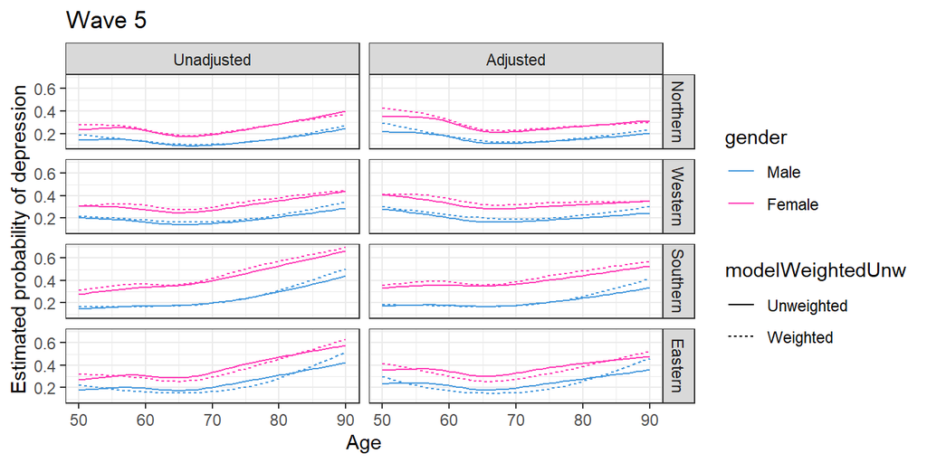

```r
mod.w5
```

```r
ggsave("out/modCI.w5.png", plot = modCI.w5, device = "png")
ggsave("out/mod.w5.png", plot = mod.w5, device = "png")
ggsave("out/prev.w5.png", plot = prev.w5, device = "png")
```

Ajdusting for risk factors furhter decreases the precision of the estimates with weighted data. Similarly to unadjusted analysis, also here the shape of the estimated probabilities was similar using or omitting weights, also after adjustment for risk factors. The major differences were observed for younger and older ages, where the variability is larger.

```r
#to display all the coefficients
#get.OR2(my.mod1)

OR.w <- get.OR2(my.mod.w)[10:20,]

df <- cbind.data.frame(OR.uw, OR.w)

kable(df, digits=2, caption = "Estimated OR from the adjusted  unweighted (leftmost) and weighted (rightmost) rcs model")
```

Estimated OR from the adjusted unweighted (leftmost) and weighted (rightmost) rcs model

|  | OR | 95% CI LL | 95% CI UL | P-value | OR | 95% CI LL | 95% CI UL | P-value |
| --- | --- | --- | --- | --- | --- | --- | --- | --- |
| bmi_imp | 1.00 | 1.00 | 1.01 | 0.24 | 1.00 | 1.00 | 1.01 | 0.28 |
| education_impMedium | 0.77 | 0.73 | 0.81 | 0.00 | 0.75 | 0.68 | 0.82 | 0.00 |
| education_impHigh | 0.66 | 0.62 | 0.70 | 0.00 | 0.58 | 0.52 | 0.66 | 0.00 |
| education_impOther | 1.03 | 0.75 | 1.40 | 0.87 | 1.11 | 0.67 | 1.82 | 0.69 |
| cusmoke_impYes | 1.33 | 1.26 | 1.40 | 0.00 | 1.39 | 1.27 | 1.53 | 0.00 |
| dis_chronic_pres1 | 1.37 | 1.30 | 1.43 | 0.00 | 1.35 | 1.25 | 1.47 | 0.00 |
| dis_chronic_pres2+ | 2.32 | 2.20 | 2.46 | 0.00 | 2.30 | 2.09 | 2.54 | 0.00 |
| pa_vigOnce a week | 0.99 | 0.93 | 1.06 | 0.86 | 0.92 | 0.81 | 1.05 | 0.21 |
| pa_vigOne to three times a month | 1.12 | 1.03 | 1.21 | 0.01 | 1.11 | 0.95 | 1.28 | 0.18 |
| pa_vigHardly ever, or never | 1.86 | 1.77 | 1.95 | 0.00 | 1.84 | 1.69 | 2.01 | 0.00 |
| living_arrangementLiving alone | 1.21 | 1.16 | 1.26 | 0.00 | 1.22 | 1.12 | 1.31 | 0.00 |

```r
#kable(get.OR2(my.mod1)[10:20,], digits=2, caption = "Estimated OR from the adjusted rcs model",     format = "latex")

OR.w5 <- df
```

The estimated OR for the risk factors obtained with weighted and unweighted analysis are similar

### 1.1.4 Analysis of the other waves

Also using the other single waves the results between weighted and unweighted analyses were similar.

The most notable difference was observed in Wave 1, where the sample was the smallest. The weighted analysis gave extremely variable estimates (for the estimated probabilities after year 65). We conducted a sensitivity analysis were we removed the participants with largest weights (<1% participants with weighted >20000): the variability was greatly reduced and the results obtained from the two analyses were very similar.

```r
#retrieval of weights from wave 1
share.data.weights <- f_readRShare(
  datadir = "sharedata",
  waves = 1,
  modules = "gv_weights",
  modules.wX = NULL  ,
  countries = NULL,
  variables.in.modules = NULL,
  keep.module.name.in.vars = FALSE,
  verbose = FALSE
)$df.w



# obtain only data from wave 1 from those used to develop the models that include all waves
share.data.w1 <- filter(share.data.first.interview, Wave=="Wave 1")

# join with variable data
share.data.w1 <- left_join(share.data.weights[,c("mergeid", "dw_w1", "cciw_w1", "subsample", "stratum1", "stratum2", "psu", "ssu")], share.data.w1,  by="mergeid")

# filter out the observations with missing weights
share.data.w1  <- filter(share.data.w1, !is.na(cciw_w1))


#dropping the participants from Israel
share.data.w1  <- filter(share.data.w1, !is.na(age_int))

#dropping unused levels
share.data.w1 <- droplevels(share.data.w1)
```

```r
# assign weights equal to 1 to all participants in an additional variable to obtain unweighted estimates
share.data.w1$wAll1 <- 1


# setting to missing the strata and psu values that are empty
share.data.w1$stratum1[share.data.w1$stratum1==""] <- NA
share.data.w1$psu[share.data.w1$psu==""] <- NA
# number of missing psu
num.na.psu <- sum(is.na(share.data.w1$psu))
share.data.w1$psu <- as.numeric(share.data.w1$psu)

# using constant values for strata within country, all different values of psu for countries that did not have them in the design
share.data.w1$stratum1[is.na(share.data.w1$stratum1)] <- paste(share.data.w1$country[is.na(share.data.w1$stratum1)], "fake stratum")
share.data.w1$psu[is.na(share.data.w1$psu)] <- c((10^9+1) :  (10^9+num.na.psu))


# specify the sampling design
dstrat <- survey::svydesign(id=~psu,strata=~stratum1, weights=~ cciw_w1,
data = share.data.w1, nest=TRUE)

# id=∼psu specifies sampling at primary sampling unit.
# stratum1 is a factor variable for stratum used for sampling, usually geographical units
# share.data.w1 is the data frame with all the data.
# cciw_w1 contains calibrated sampling weights

# remove the participants not used in the analysis - removed because of missing data or exclusion criteria
dstrat <- subset(dstrat, !is.na(eurodcat_imp))

#to take into account the problem related to strata with a single psu
options(survey.lonely.psu="adjust")



# Create summary data, weighted
lr_gen_w1_d <- share.data.w1  %>%
  as_survey_design(weights = c(cciw_w1), ids = psu, strata = stratum1, nest= TRUE) %>% subset(!is.na(eurodcat_imp)) %>%
  group_by(region, gender) %>%
  summarize(n = survey_mean(eurodcat_imp, na.rm = T, vartype = "ci"))


# Create summary data, weighted
lr_gen_un <- share.data.w1  %>%
  as_survey_design(weights = c(wAll1)) %>% subset(!is.na(eurodcat_imp)) %>%
  group_by(region, gender) %>%
  summarize(n = survey_mean(eurodcat_imp, na.rm = T, vartype = "ci"))


# Create summary data, weighted but without design information
lr_gen_w1 <- share.data.w1  %>%
  as_survey_design(weights = c(cciw_w1)) %>% subset(!is.na(eurodcat_imp)) %>%
  group_by(region, gender) %>%
  summarize(n = survey_mean(eurodcat_imp, na.rm = T, vartype = "ci"))



 df <- cbind.data.frame(lr_gen_un, lr_gen_w1_d[, c("n", "n_low", "n_upp")], lr_gen_w1[, c("n", "n_low", "n_upp")] )
dimnames(df)[[2]] <- c("Region", "Gender", "Depression prob - UW", "CI LL - UW", "CI UL - UW",
                       "Depression prob - W,D", "CI LL - W,D", "CI UL - W,D",
                       "Depression prob - W", "CI LL - W", "CI UL - W"
                        )

tab.w1 <- df

#kable(df, digits=2, caption="Prevalence of depression and 95% CI stratified by gender and region; UW: unweighted, W: weighted using calibration weights, D: using sampling design.")


#svymean(~eurodcat_imp, dstrat, na.rm=TRUE)




#kable(cbind.data.frame(lr_gen_un, lr_gen_w1[, c("n", "n_low", "n_upp")]), digits=2, caption="Unweighted (left) and weighted (right) prevalence of depression, #stratified by gender and region.")


# Plot proportion with depression
prev.w1 <- ggplot(lr_gen_w1, aes(x = gender, y = n)) +
  geom_bar(aes(fill = gender), stat = "identity") +
  geom_errorbar(aes(ymin = n_low, max = n_upp), width = 0.2) +
  facet_wrap(~region) +
  theme_bw() + geom_point(data=lr_gen_un, aes(gender, y=n)) + ggtitle("Wave 1") + labs(y="Proportion with depression") #adding unweighted data


# Plot it
#ggplot(lr_gen, aes(x = gender, y = n)) +
#  geom_bar(aes(fill = gender), stat = "identity") +
#  geom_errorbar(aes(ymin = n_low, max = n_upp), width = 0.2) +
#  facet_wrap(~region) +
#  theme_bw()



#overall weighted estimate
#share.data.w1  %>%
#     as_survey_design(weights = c(cciw_w1)) %>% subset(!is.na(eurodcat_imp)) %$% svymean(~eurodcat_imp, .)

#unweighted estimate
#prop.test(table(share.data.w1$eurodcat_imp==0))
```

```r
my.mod <- glm(eurodcat_imp ~ rcs(age_int_stand) + gender + region +
                       rcs(age_int_stand):region + rcs(age_int_stand):gender + gender:region ,
                                             data=share.data.w1, family="binomial",  x=TRUE, y=TRUE)

#save the spline terms in the complete data set for further use
share.data.w1 <- share.data.w1 %>% mutate(age1 = my.mod$x[,2],
                                                                    age2 = my.mod$x[,3],
                                                                    age3 = my.mod$x[,4],
                                                                    age4 = my.mod$x[,5])


# retrieve the location of knots used and assign them to Knots variable
Knots <- Hmisc::rcspline.eval(x = share.data.w1$age_int_stand, nk = 5, knots.only = TRUE)

#reproduces the spline values for age, expands for each integer value from 50 to 90
age = rcspline.eval(c(50:90)-50, knots=Knots)
age <- cbind.data.frame(age1=c(50:90)-50, age )
dimnames(age)[[2]] <- c("age1", "age2", "age3", "age4")






if(!is.null(my.mod$na.action)){
my.mod2 <- glm(eurodcat_imp ~ age1 + age2 + age3 + age4 + gender + region +
                      age1:region + age2:region + age3:region + age4:region +
                       age1:gender + age2:gender + age3:gender + age4:gender +
                       gender:region ,
                        data=share.data.w1[-my.mod$na.action,], family="binomial",  x=TRUE, y=TRUE)} else {
 my.mod2 <- glm(eurodcat_imp ~ age1 + age2 + age3 + age4 + gender + region +
                      age1:region + age2:region + age3:region + age4:region +
                       age1:gender + age2:gender + age3:gender + age4:gender +
                       gender:region ,
                        data=share.data.w1, family="binomial",  x=TRUE, y=TRUE)
}





#derive the data.frame containing the levels of the covariatee, where the probabilities of depression estimated by the model will be derived
data.grid <- expand.grid(age1=age[,1], gender=levels(share.data.w1$gender), region=levels(share.data.w1$region))
data.grid <- left_join(data.grid, age, by="age1" )

#data.grid <- filter(data.grid, is.element(region, c("Austria", "Spain", "Italy", "France", "Belgium", "Israel")))
data.grid.region <- data.grid


#defining also data grid for countries
data.grid.region <- expand.grid(age1=age[,1], gender=levels(share.data.w1$gender), region=levels(share.data.w1$region))
data.grid.region <- left_join(data.grid.region, age, by="age1" )




#derive the predicted probabilities
my.pred <- predict(my.mod2, newdata=data.grid, se.fit = TRUE, type="response")

#join the levels of the covariates and the predicted probabilities
my.pred.all <- cbind.data.frame(data.grid, my.pred)

#saving the estimates from the 2-way models
pred.age_unadjusted_region_rcs <- my.pred.all
```

```r
ggplot(my.pred.all, aes(age1+50, fit, color=gender)) + geom_line() + facet_wrap(region~., ncol=5) + labs(x="Age", y="Estimated probability of depression") + scale_color_manual(values=c("#4699dd","#ff3db7" )) + ggtitle("Unadjusted - (gender, region, rcs(age))") +
  geom_ribbon(aes(ymin = fit - 1.96*se.fit, ymax = fit + 1.96*se.fit), alpha = 0.2, linetype=0) +  theme_bw()


#my.pred.all %>% left_join(select(share.data.w1, starts_with("region")), by="region") %>% ggplot(aes(age1, fit, #color=gender))+ geom_point() + facet_grid(.~regionGroup) + labs(x="Age", y="Estimated probability of depression") + #scale_color_manual(values=c("#4699dd","#ff3db7" ))


anova(my.mod, test="Chi")
```

```r
 my.mod.w <- svyglm(eurodcat_imp ~ age1 + age2 + age3 + age4 + gender + region +
                      age1:region + age2:region + age3:region + age4:region +
                       age1:gender + age2:gender + age3:gender + age4:gender +
                       gender:region ,
                        design=dstrat, family="binomial",  x=TRUE, y=TRUE)




#derive the predicted probabilities
my.pred <- predict(my.mod.w, newdata=data.grid, se.fit = TRUE, type="response")
#join the levels of the covariates and the predicted probabilities
my.pred.all <- cbind.data.frame(data.grid, my.pred)

my.pred.all <- pred.age_unadjusted_region_rcs_w<- rename(my.pred.all, fit=response, se.fit = SE)
pred.age_unadjusted_region_rcs_w <- mutate(pred.age_unadjusted_region_rcs_w, residual.scale = 1)

pred.age_all <- rbind.data.frame(pred.age_unadjusted_region_rcs,pred.age_unadjusted_region_rcs_w)
pred.age_all <- mutate(pred.age_all, model=c(rep("Unadjusted \n rcs", nrow(pred.age_unadjusted_region_rcs)), rep("Unadjusted weighted \n rcs", nrow(pred.age_unadjusted_region_rcs))))

#saving the estimates from the 2-way models
pred.age_unadjusted_region_rcs <- my.pred.all




#ggplot(my.pred.all, aes(age1+50, fit, color=gender)) + geom_line() + facet_wrap(region~., ncol=5) + labs(x="Age", y="Estimated probability of depression") + scale_color_manual(values=c("#4699dd","#ff3db7" )) + ggtitle("Unadjusted and weighted - (gender, region, rcs(age))") +
#  geom_ribbon(aes(ymin = fit - 1.96*se.fit, ymax = fit + 1.96*se.fit), alpha = 0.2, linetype=0) +  theme_bw()


#my.pred.all %>% left_join(select(share.data.w1, starts_with("region")), by="region") %>% ggplot(aes(age1, fit, #color=gender))+ geom_point() + facet_grid(.~regionGroup) + labs(x="Age", y="Estimated probability of depression") + #scale_color_manual(values=c("#4699dd","#ff3db7" ))


#anova(my.mod.w, test="Chi")



modCI.w1 <- ggplot(pred.age_all, aes(age1+50, fit, color=gender)) + geom_line() + facet_grid(region~model) + labs(x="Age", y="Estimated probability of depression") + scale_color_manual(values=c("#4699dd","#ff3db7" )) + ggtitle("Unadjusted, comparsion of weighted and unweighted - (gender, region, rcs(age))") +
  geom_ribbon(aes(ymin = fit - 1.96*se.fit, ymax = fit + 1.96*se.fit), alpha = 0.2, linetype=0) +  theme_bw()

mod.w1 <- ggplot(pred.age_all, aes(age1+50, fit, color=gender)) + geom_line(aes(linetype=model)) + facet_grid(region~.) + labs(x="Age", y="Estimated probability of depression") + scale_color_manual(values=c("#4699dd","#ff3db7" )) + ggtitle("Unadjusted comparison of weighted and unweighted - (gender, region, rcs(age))") +
 # geom_ribbon(aes(ymin = fit - 1.96*se.fit, ymax = fit + 1.96*se.fit), alpha = 0.2, linetype=0) +
  theme_bw()
```

```r
my.mod2  <- glm(
  eurodcat_imp ~
    age1 + age2 + age3 + age4 + gender + region +
    bmi_imp + education_imp + cusmoke_imp + dis_chronic_pres +
    pa_vig + living_arrangement +
    age1:region + age2:region + age3:region + age4:region +
    age1:gender + age2:gender + age3:gender + age4:gender +
    gender:region,
  data = share.data.w1,
  family = "binomial",
  x = TRUE,
  y = TRUE
)



my.mod1  <- glm(
  eurodcat_imp ~
    rcspline.eval(age_int_stand, knots=Knots, inclx = TRUE) + gender + region +
    bmi_imp + education_imp + cusmoke_imp + dis_chronic_pres +
    pa_vig + living_arrangement +
     rcspline.eval(age_int_stand, knots=Knots, inclx = TRUE):region +
     rcspline.eval(age_int_stand, knots=Knots, inclx = TRUE):gender +
    gender:region,
  data = share.data.w1,
  family = "binomial",
  x = TRUE,
  y = TRUE
)



data.grid.adj <- expand.grid(age1=unique(share.data.w1$age1), gender=levels(share.data.w1$gender), region=levels(share.data.w1$region),
                         #overall mean
                         #bmi_10 = mean(share.data.w1$bmi_imp, na.rm=TRUE),

                      education_imp ="Low", cusmoke_imp="No",  dis_chronic_pres="0",
                        pa_vig = "Hardly ever, or never" ,  living_arrangement="Living with partner"
                         )


#using median bmi, separate evaluation by gender

data.grid.adj <- left_join(data.grid.adj,
          share.data.w1 %>% group_by(gender) %>%
            #rename(age1 = age_int_stand) %>%
            summarise(bmi_imp=median(bmi_imp, na.rm=TRUE)),
           by=c("gender"))

data.grid.adj <- left_join(data.grid.adj, age, by="age1")
data.grid.adj.region <- data.grid.adj



#defining also data grid for countries
data.grid.adj.region <- expand.grid(age1=unique(share.data.w1$age1), gender=levels(share.data.w1$gender), region=levels(share.data.w1$region),
                         #overall mean
                         #bmi_10 = mean(share.data.w1$bmi_imp, na.rm=TRUE),

                      education_imp ="Low", cusmoke_imp="No",  dis_chronic_pres="0",
                        pa_vig = "Hardly ever, or never" ,  living_arrangement="Living with partner"
                         )
data.grid.adj.region <- left_join(data.grid.adj.region,
          share.data.w1 %>% group_by(gender) %>%
            #rename(age1 = age_int_stand) %>%
            summarise(bmi_imp=median(bmi_imp, na.rm=TRUE)),
           by=c("gender"))

data.grid.adj.region <- left_join(data.grid.adj.region, age, by="age1")


#derive the predicted probabilities
my.pred <- predict(my.mod2, newdata=data.grid.adj, se.fit = TRUE, type="response")

#join the levels of the covariates and the predicted probabilities
my.pred.all <- cbind.data.frame(data.grid.adj, my.pred)

#saving the estimates from the 2-way models
pred.age_adjusted_region_rcs <- my.pred.all


pred.age_adjusted_region_rcs <- mutate( pred.age_adjusted_region_rcs ,  "education_imp"=NA,      "cusmoke_imp"=NA  ,      "dis_chronic_pres"=NA  ,  "pa_vig" = NA,  "living_arrangement" = NA,  "bmi_imp" = NA,  "age2" = NA        ,       "age3" = NA ,              "age4" = NA    )
pred.age_adjusted_region_rcs<- mutate(pred.age_adjusted_region_rcs, model="Adjusted \n rcs")


pred.age_all <- mutate(pred.age_all,
                     "education_imp"=NA,      "cusmoke_imp"=NA  ,      "dis_chronic_pres"=NA  ,  "pa_vig" = NA,  "living_arrangement" = NA,  "bmi_imp" = NA )



pred.age_all <- rbind.data.frame(pred.age_all, pred.age_adjusted_region_rcs)
```

```r
ggplot(my.pred.all, aes(age1+50, fit, color=gender)) + geom_line() + facet_wrap(region~., ncol=5) + labs(x="Age", y="Estimated probability of depression") + scale_color_manual(values=c("#4699dd","#ff3db7" )) + ggtitle("Adjusted estimates (gender, region, rcs(age))") +
  geom_ribbon(aes(ymin = fit - 1.96*se.fit, ymax = fit + 1.96*se.fit), alpha = 0.2, linetype=0) +  theme_bw()


anova(my.mod1, test="Chi")
```

```r
#to display all the coefficients
#get.OR2(my.mod1)


#kable(get.OR2(my.mod1)[9:19,], digits=2, caption = "Estimated OR from the adjusted rcs model")
#kable(get.OR2(my.mod1)[10:20,], digits=2, caption = "Estimated OR from the adjusted rcs model",     format = "latex")


OR.uw <- get.OR2(my.mod1)[9:19,]
```

```r
#dstrat <- svydesign(id=~psu,strata=~stratum1, weights=~ cciw_w1,
#data=share.data.w1, nest=TRUE)


 my.mod.w <- svyglm(eurodcat_imp ~
    age1 + age2 + age3 + age4 + gender + region +
    bmi_imp + education_imp + cusmoke_imp + dis_chronic_pres +
    pa_vig + living_arrangement +
    age1:region + age2:region + age3:region + age4:region +
    age1:gender + age2:gender + age3:gender + age4:gender +
    gender:region,
                        design=dstrat, family="binomial",  x=TRUE, y=TRUE)




#derive the predicted probabilities
my.pred <- predict(my.mod.w, newdata=data.grid.adj.region, se.fit = TRUE, type="response")
#join the levels of the covariates and the predicted probabilities
my.pred.all <- cbind.data.frame(data.grid.adj.region, my.pred)

my.pred.all <- pred.age_unadjusted_region_rcs_w<- rename(my.pred.all, fit=response, se.fit = SE)
pred.age_adjusted_region_rcs_w <- mutate(pred.age_unadjusted_region_rcs_w, residual.scale = 1, model = "Adjusted weighted \n rcs")

pred.age_all <- rbind.data.frame(pred.age_all, pred.age_adjusted_region_rcs_w)

#saving the estimates from the 2-way models
pred.age_adjusted_region_rcs_w <- my.pred.all

#ggplot(my.pred.all, aes(age1+50, fit, color=gender)) + geom_line() + facet_wrap(region~., ncol=5) + labs(x="Age", y="Estimated probability of depression") + scale_color_manual(values=c("#4699dd","#ff3db7" )) + ggtitle("Adjusted - (gender, region, rcs(age))") +
 # geom_ribbon(aes(ymin = fit - 1.96*se.fit, ymax = fit + 1.96*se.fit), alpha = 0.2, linetype=0) +  theme_bw()


#my.pred.all %>% left_join(select(share.data.w1, starts_with("region")), by="region") %>% ggplot(aes(age1, fit, #color=gender))+ geom_point() + facet_grid(.~regionGroup) + labs(x="Age", y="Estimated probability of depression") + #scale_color_manual(values=c("#4699dd","#ff3db7" ))


#anova(my.mod.w, test="Chi")

pred.age_all$modelAdjUnadj <- pred.age_all$modelWeightedUnw <- pred.age_all$model

level_key <- c(`Unadjusted \n rcs` = "Unadjusted", `Unadjusted weighted \n rcs` = "Unadjusted",
               `Adjusted \n rcs` = "Adjusted", `Adjusted weighted \n rcs` = "Adjusted"
                 )

pred.age_all$modelAdjUnadj <- recode_factor(pred.age_all$modelAdjUnadj, !!!level_key)


level_key <- c(`Unadjusted \n rcs` = "Unweighted", `Unadjusted weighted \n rcs` = "Weighted",
               `Adjusted \n rcs` = "Unweighted", `Adjusted weighted \n rcs` = "Weighted"
                 )

pred.age_all$modelWeightedUnw <- recode_factor(pred.age_all$modelWeightedUnw, !!!level_key)



modCI.w1<- ggplot(pred.age_all, aes(age1+50, fit, color=gender)) + geom_line() + facet_grid(region~model) + labs(x="Age", y="Estimated probability of depression") + scale_color_manual(values=c("#4699dd","#ff3db7" )) + ggtitle("Wave 1") +
  geom_ribbon(aes(ymin = fit - 1.96*se.fit, ymax = fit + 1.96*se.fit), alpha = 0.2, linetype=0) +  theme_bw()

mod.w1<- ggplot(pred.age_all, aes(age1+50, fit, color=gender)) + geom_line(aes(linetype=modelWeightedUnw)) + facet_grid(region~modelAdjUnadj) + labs(x="Age", y="Estimated probability of depression") + scale_color_manual(values=c("#4699dd","#ff3db7" )) + ggtitle("Wave 1") +
 # geom_ribbon(aes(ymin = fit - 1.96*se.fit, ymax = fit + 1.96*se.fit), alpha = 0.2, linetype=0) +
  theme_bw()

ggsave("out/modCI.w1.png", plot = modCI.w1, device = "png")
ggsave("out/mod.w1.png", plot = mod.w1, device = "png")
ggsave("out/prev.w1.png", plot = prev.w1, device = "png")
```

```r
#to display all the coefficients
#get.OR2(my.mod1)

OR.w <- get.OR2(my.mod.w)[9:19,]

OR.w1 <- df <- cbind.data.frame(OR.uw, OR.w)

#kable(df, digits=2, caption = "Estimated OR from the adjusted  unweighted (leftmost) and weighted (rightmost) rcs model")
#kable(get.OR2(my.mod1)[10:20,], digits=2, caption = "Estimated OR from the adjusted rcs model",     format = "latex")
```

```r
# Wave 2 Start


#retrieval of weights from wave 1
share.data.weights <- f_readRShare(
  datadir = "sharedata",
  waves = 2,
  modules = "gv_weights",
  modules.wX = NULL  ,
  countries = NULL,
  variables.in.modules = NULL,
  keep.module.name.in.vars = FALSE,
  verbose = FALSE
)$df.w



# obtain only data from wave 1 from those used to develop the models that include all waves
share.data.w1 <- filter(share.data$df.w, Wave=="Wave 2")
share.data.w1 <- mutate(share.data.w1, age_int_stand = age_int -50)

# join with variable data
share.data.w1 <- left_join(share.data.weights[,c("mergeid", "dw_w2", "cciw_w2", "subsample", "stratum1", "stratum2", "psu", "ssu")], share.data.w1,  by="mergeid")

# filter out the observations with missing weights
share.data.w1  <- filter(share.data.w1, !is.na(cciw_w2))


#dropping the participants from Israel
share.data.w1  <- filter(share.data.w1, country != "Israel")

#dropping unused levels
share.data.w1 <- droplevels(share.data.w1)
```

```r
# assign weights equal to 1 to all participants in an additional variable to obtain unweighted estimates
share.data.w1$wAll1 <- 1


# setting to missing the strata and psu values that are empty
share.data.w1$stratum1[share.data.w1$stratum1==""] <- NA
share.data.w1$psu[share.data.w1$psu==""] <- NA
# number of missing psu
num.na.psu <- sum(is.na(share.data.w1$psu))
share.data.w1$psu <- as.numeric(share.data.w1$psu)

# using constant values for strata within country, all different values of psu for countries that did not have them in the design
share.data.w1$stratum1[is.na(share.data.w1$stratum1)] <- paste(share.data.w1$country[is.na(share.data.w1$stratum1)], "fake stratum")
share.data.w1$psu[is.na(share.data.w1$psu)] <- c((10^9+1) :  (10^9+num.na.psu))


# specify the sampling design
dstrat <- survey::svydesign(id=~psu,strata=~stratum1, weights=~ cciw_w2,
data = share.data.w1, nest=TRUE)

# id=∼psu specifies sampling at primary sampling unit.
# stratum1 is a factor variable for stratum used for sampling, usually geographical units
# share.data.w1 is the data frame with all the data.
# cciw_w2 contains calibrated sampling weights

# remove the participants not used in the analysis - removed because of missing data or exclusion criteria
dstrat <- subset(dstrat, !is.na(eurodcat_imp))

#to take into account the problem related to strata with a single psu
options(survey.lonely.psu="adjust")



# Create summary data, weighted
lr_gen_w1_d <- share.data.w1  %>%
  as_survey_design(weights = c(cciw_w2), ids = psu, strata = stratum1, nest= TRUE) %>% subset(!is.na(eurodcat_imp)) %>%
  group_by(region, gender) %>%
  summarize(n = survey_mean(eurodcat_imp, na.rm = T, vartype = "ci"))


# Create summary data, weighted
lr_gen_un <- share.data.w1  %>%
  as_survey_design(weights = c(wAll1)) %>% subset(!is.na(eurodcat_imp)) %>%
  group_by(region, gender) %>%
  summarize(n = survey_mean(eurodcat_imp, na.rm = T, vartype = "ci"))


# Create summary data, weighted but without design information
lr_gen_w1 <- share.data.w1  %>%
  as_survey_design(weights = c(cciw_w2)) %>% subset(!is.na(eurodcat_imp)) %>%
  group_by(region, gender) %>%
  summarize(n = survey_mean(eurodcat_imp, na.rm = T, vartype = "ci"))



df <- cbind.data.frame(lr_gen_un, lr_gen_w1_d[, c("n", "n_low", "n_upp")], lr_gen_w1[, c("n", "n_low", "n_upp")] )
dimnames(df)[[2]] <- c("Region", "Gender", "Depression prob - UW", "CI LL - UW", "CI UL - UW",
                       "Depression prob - W,D", "CI LL - W,D", "CI UL - W,D",
                       "Depression prob - W", "CI LL - W", "CI UL - W"
                        )
tab.w2 <- df
#kable(df, digits=2, caption="Prevalence of depression and 95% CI stratified by gender and region; UW: unweighted, W: weighted using calibration weights, D: using sampling design.")


#svymean(~eurodcat_imp, dstrat, na.rm=TRUE)




#kable(cbind.data.frame(lr_gen_un, lr_gen_w1[, c("n", "n_low", "n_upp")]), digits=2, caption="Unweighted (left) and weighted (right) prevalence of depression, #stratified by gender and region.")


# Plot proportion with depression
prev.w2 <- ggplot(lr_gen_w1, aes(x = gender, y = n)) +
  geom_bar(aes(fill = gender), stat = "identity") +
  geom_errorbar(aes(ymin = n_low, max = n_upp), width = 0.2) +
  facet_wrap(~region) +
  theme_bw() + geom_point(data=lr_gen_un, aes(gender, y=n)) + ggtitle("Wave 2") + labs(y="Proportion with depression") #adding unweighted data


# Plot it
#ggplot(lr_gen, aes(x = gender, y = n)) +
#  geom_bar(aes(fill = gender), stat = "identity") +
#  geom_errorbar(aes(ymin = n_low, max = n_upp), width = 0.2) +
#  facet_wrap(~region) +
#  theme_bw()



#overall weighted estimate
#share.data.w1  %>%
#     as_survey_design(weights = c(cciw_w2)) %>% subset(!is.na(eurodcat_imp)) %$% svymean(~eurodcat_imp, .)

#unweighted estimate
#prop.test(table(share.data.w1$eurodcat_imp==0))
```

```r
my.mod <- lm(gender ~ rcs(age_int_stand) ,
                                             data=share.data.w1[, ], family="binomial",  x=TRUE, y=TRUE)

#save the spline terms in the complete data set for further use
share.data.w1 <- share.data.w1 %>% mutate(age1 = my.mod$x[,2],
                                                                    age2 = my.mod$x[,3],
                                                                    age3 = my.mod$x[,4],
                                                                    age4 = my.mod$x[,5])


my.mod <- glm(eurodcat_imp ~ rcs(age_int_stand) + gender + region +
                       rcs(age_int_stand):region + rcs(age_int_stand):gender + gender:region ,
                                             data=share.data.w1, family="binomial",  x=TRUE, y=TRUE)


# retrieve the location of knots used and assign them to Knots variable
Knots <- Hmisc::rcspline.eval(x = share.data.w1$age_int_stand, nk = 5, knots.only = TRUE)

#reproduces the spline values for age, expands for each integer value from 50 to 90
age = rcspline.eval(c(50:90)-50, knots=Knots)
age <- cbind.data.frame(age1=c(50:90)-50, age )
dimnames(age)[[2]] <- c("age1", "age2", "age3", "age4")






if(!is.null(my.mod$na.action)){
my.mod2 <- glm(eurodcat_imp ~ age1 + age2 + age3 + age4 + gender + region +
                      age1:region + age2:region + age3:region + age4:region +
                       age1:gender + age2:gender + age3:gender + age4:gender +
                       gender:region ,
                        data=share.data.w1[-my.mod$na.action,], family="binomial",  x=TRUE, y=TRUE)} else {
 my.mod2 <- glm(eurodcat_imp ~ age1 + age2 + age3 + age4 + gender + region +
                      age1:region + age2:region + age3:region + age4:region +
                       age1:gender + age2:gender + age3:gender + age4:gender +
                       gender:region ,
                        data=share.data.w1, family="binomial",  x=TRUE, y=TRUE)
}





#derive the data.frame containing the levels of the covariatee, where the probabilities of depression estimated by the model will be derived
data.grid <- expand.grid(age1=age[,1], gender=levels(share.data.w1$gender), region=levels(share.data.w1$region))
data.grid <- left_join(data.grid, age, by="age1" )

#data.grid <- filter(data.grid, is.element(region, c("Austria", "Spain", "Italy", "France", "Belgium", "Israel")))
data.grid.region <- data.grid


#defining also data grid for countries
data.grid.region <- expand.grid(age1=age[,1], gender=levels(share.data.w1$gender), region=levels(share.data.w1$region))
data.grid.region <- left_join(data.grid.region, age, by="age1" )




#derive the predicted probabilities
my.pred <- predict(my.mod2, newdata=data.grid, se.fit = TRUE, type="response")

#join the levels of the covariates and the predicted probabilities
my.pred.all <- cbind.data.frame(data.grid, my.pred)

#saving the estimates from the 2-way models
pred.age_unadjusted_region_rcs <- my.pred.all
```

```r
ggplot(my.pred.all, aes(age1+50, fit, color=gender)) + geom_line() + facet_wrap(region~., ncol=5) + labs(x="Age", y="Estimated probability of depression") + scale_color_manual(values=c("#4699dd","#ff3db7" )) + ggtitle("Unadjusted - (gender, region, rcs(age))") +
  geom_ribbon(aes(ymin = fit - 1.96*se.fit, ymax = fit + 1.96*se.fit), alpha = 0.2, linetype=0) +  theme_bw()


#my.pred.all %>% left_join(select(share.data.w1, starts_with("region")), by="region") %>% ggplot(aes(age1, fit, #color=gender))+ geom_point() + facet_grid(.~regionGroup) + labs(x="Age", y="Estimated probability of depression") + #scale_color_manual(values=c("#4699dd","#ff3db7" ))


#anova(my.mod, test="Chi")
```

```r
# specify the sampling design
dstrat <- survey::svydesign(id=~psu,strata=~stratum1, weights=~ cciw_w2,
data = share.data.w1, nest=TRUE)


# remove the participants not used in the analysis - removed because of missing data or exclusion criteria
dstrat <- subset(dstrat, !is.na(eurodcat_imp))

 my.mod.w <- svyglm(eurodcat_imp ~ age1 + age2 + age3 + age4 + gender + region +
                      age1:region + age2:region + age3:region + age4:region +
                       age1:gender + age2:gender + age3:gender + age4:gender +
                       gender:region ,
                        design=dstrat, family="binomial",  x=TRUE, y=TRUE)




#derive the predicted probabilities
my.pred <- predict(my.mod.w, newdata=data.grid, se.fit = TRUE, type="response")
#join the levels of the covariates and the predicted probabilities
my.pred.all <- cbind.data.frame(data.grid, my.pred)

my.pred.all <- pred.age_unadjusted_region_rcs_w<- rename(my.pred.all, fit=response, se.fit = SE)
pred.age_unadjusted_region_rcs_w <- mutate(pred.age_unadjusted_region_rcs_w, residual.scale = 1)

pred.age_all <- rbind.data.frame(pred.age_unadjusted_region_rcs,pred.age_unadjusted_region_rcs_w)
pred.age_all <- mutate(pred.age_all, model=c(rep("Unadjusted \n rcs", nrow(pred.age_unadjusted_region_rcs)), rep("Unadjusted weighted \n rcs", nrow(pred.age_unadjusted_region_rcs))))

#saving the estimates from the 2-way models
pred.age_unadjusted_region_rcs <- my.pred.all




a <- ggplot(my.pred.all, aes(age1+50, fit, color=gender)) + geom_line() + facet_wrap(region~., ncol=5) + labs(x="Age", y="Estimated probability of depression") + scale_color_manual(values=c("#4699dd","#ff3db7" )) + ggtitle("Unadjusted and weighted - (gender, region, rcs(age))") +
  geom_ribbon(aes(ymin = fit - 1.96*se.fit, ymax = fit + 1.96*se.fit), alpha = 0.2, linetype=0) +  theme_bw()


#my.pred.all %>% left_join(select(share.data.w1, starts_with("region")), by="region") %>% ggplot(aes(age1, fit, #color=gender))+ geom_point() + facet_grid(.~regionGroup) + labs(x="Age", y="Estimated probability of depression") + #scale_color_manual(values=c("#4699dd","#ff3db7" ))


#anova(my.mod.w, test="Chi")



b <- ggplot(pred.age_all, aes(age1+50, fit, color=gender)) + geom_line() + facet_grid(region~model) + labs(x="Age", y="Estimated probability of depression") + scale_color_manual(values=c("#4699dd","#ff3db7" )) + ggtitle("Unadjusted, comparsion of weighted and unweighted - (gender, region, rcs(age))") +
  geom_ribbon(aes(ymin = fit - 1.96*se.fit, ymax = fit + 1.96*se.fit), alpha = 0.2, linetype=0) +  theme_bw()

a <- ggplot(pred.age_all, aes(age1+50, fit, color=gender)) + geom_line(aes(linetype=model)) + facet_grid(region~.) + labs(x="Age", y="Estimated probability of depression") + scale_color_manual(values=c("#4699dd","#ff3db7" )) + ggtitle("Unadjusted comparison of weighted and unweighted - (gender, region, rcs(age))") +
 # geom_ribbon(aes(ymin = fit - 1.96*se.fit, ymax = fit + 1.96*se.fit), alpha = 0.2, linetype=0) +
  theme_bw()
```

```r
my.mod2  <- glm(
  eurodcat_imp ~
    age1 + age2 + age3 + age4 + gender + region +
    bmi_imp + education_imp + cusmoke_imp + dis_chronic_pres +
    pa_vig + living_arrangement +
    age1:region + age2:region + age3:region + age4:region +
    age1:gender + age2:gender + age3:gender + age4:gender +
    gender:region,
  data = share.data.w1,
  family = "binomial",
  x = TRUE,
  y = TRUE
)



my.mod1  <- glm(
  eurodcat_imp ~
    rcspline.eval(age_int_stand, knots=Knots, inclx = TRUE) + gender + region +
    bmi_imp + education_imp + cusmoke_imp + dis_chronic_pres +
    pa_vig + living_arrangement +
     rcspline.eval(age_int_stand, knots=Knots, inclx = TRUE):region +
     rcspline.eval(age_int_stand, knots=Knots, inclx = TRUE):gender +
    gender:region,
  data = share.data.w1,
  family = "binomial",
  x = TRUE,
  y = TRUE
)


data.grid.adj <- expand.grid(age1=unique(share.data.w1$age1), gender=levels(share.data.w1$gender), region=levels(share.data.w1$region),
                         #overall mean
                         #bmi_10 = mean(share.data.w1$bmi_imp, na.rm=TRUE),

                      education_imp ="Low", cusmoke_imp="No",  dis_chronic_pres="0",
                        pa_vig = "Hardly ever, or never" ,  living_arrangement="Living with partner"
                         )


#using median bmi, separate evaluation by gender

data.grid.adj <- left_join(data.grid.adj,
          share.data.w1 %>% group_by(gender) %>%
            #rename(age1 = age_int_stand) %>%
            summarise(bmi_imp=median(bmi_imp, na.rm=TRUE)),
           by=c("gender"))

data.grid.adj <- left_join(data.grid.adj, age, by="age1")
data.grid.adj.region <- data.grid.adj



#defining also data grid for countries
data.grid.adj.region <- expand.grid(age1=unique(share.data.w1$age1), gender=levels(share.data.w1$gender), region=levels(share.data.w1$region),
                         #overall mean
                         #bmi_10 = mean(share.data.w1$bmi_imp, na.rm=TRUE),

                      education_imp ="Low", cusmoke_imp="No",  dis_chronic_pres="0",
                        pa_vig = "Hardly ever, or never" ,  living_arrangement="Living with partner"
                         )
data.grid.adj.region <- left_join(data.grid.adj.region,
          share.data.w1 %>% group_by(gender) %>%
            #rename(age1 = age_int_stand) %>%
            summarise(bmi_imp=median(bmi_imp, na.rm=TRUE)),
           by=c("gender"))

data.grid.adj.region <- left_join(data.grid.adj.region, age, by="age1")


#derive the predicted probabilities
my.pred <- predict(my.mod2, newdata=data.grid.adj, se.fit = TRUE, type="response")

#join the levels of the covariates and the predicted probabilities
my.pred.all <- cbind.data.frame(data.grid.adj, my.pred)

#saving the estimates from the 2-way models
pred.age_adjusted_region_rcs <- my.pred.all


pred.age_adjusted_region_rcs <- mutate( pred.age_adjusted_region_rcs ,  "education_imp"=NA,      "cusmoke_imp"=NA  ,      "dis_chronic_pres"=NA  ,  "pa_vig" = NA,  "living_arrangement" = NA,  "bmi_imp" = NA,  "age2" = NA        ,       "age3" = NA ,              "age4" = NA    )
pred.age_adjusted_region_rcs<- mutate(pred.age_adjusted_region_rcs, model="Adjusted \n rcs")


pred.age_all <- mutate(pred.age_all,
                     "education_imp"=NA,      "cusmoke_imp"=NA  ,      "dis_chronic_pres"=NA  ,  "pa_vig" = NA,  "living_arrangement" = NA,  "bmi_imp" = NA )



pred.age_all <- rbind.data.frame(pred.age_all, pred.age_adjusted_region_rcs)
```

```r
ggplot(my.pred.all, aes(age1+50, fit, color=gender)) + geom_line() + facet_wrap(region~., ncol=5) + labs(x="Age", y="Estimated probability of depression") + scale_color_manual(values=c("#4699dd","#ff3db7" )) + ggtitle("Adjusted estimates (gender, region, rcs(age))") +
  geom_ribbon(aes(ymin = fit - 1.96*se.fit, ymax = fit + 1.96*se.fit), alpha = 0.2, linetype=0) +  theme_bw()


#anova(my.mod1, test="Chi")
```

```r
#to display all the coefficients
#get.OR2(my.mod1)


#kable(get.OR2(my.mod1)[10:20,], digits=2, caption = "Estimated OR from the adjusted rcs model")
#kable(get.OR2(my.mod1)[10:20,], digits=2, caption = "Estimated OR from the adjusted rcs model",     format = "latex")


OR.uw <- get.OR2(my.mod1)[10:20,]
```

```r
#dstrat <- svydesign(id=~psu,strata=~stratum1, weights=~ cciw_w4,
#data=share.data.w1, nest=TRUE)


 my.mod.w <- svyglm(eurodcat_imp ~
    age1 + age2 + age3 + age4 + gender + region +
    bmi_imp + education_imp + cusmoke_imp + dis_chronic_pres +
    pa_vig + living_arrangement +
    age1:region + age2:region + age3:region + age4:region +
    age1:gender + age2:gender + age3:gender + age4:gender +
    gender:region,
                        design=dstrat, family="binomial",  x=TRUE, y=TRUE)




#derive the predicted probabilities
my.pred <- predict(my.mod.w, newdata=data.grid.adj.region, se.fit = TRUE, type="response")
#join the levels of the covariates and the predicted probabilities
my.pred.all <- cbind.data.frame(data.grid.adj.region, my.pred)

my.pred.all <- pred.age_unadjusted_region_rcs_w<- rename(my.pred.all, fit=response, se.fit = SE)
pred.age_adjusted_region_rcs_w <- mutate(pred.age_unadjusted_region_rcs_w, residual.scale = 1, model = "Adjusted weighted \n rcs")

pred.age_all <- rbind.data.frame(pred.age_all, pred.age_adjusted_region_rcs_w)

#saving the estimates from the 2-way models
pred.age_adjusted_region_rcs_w <- my.pred.all

#ggplot(my.pred.all, aes(age1+50, fit, color=gender)) + geom_line() + facet_wrap(region~., ncol=5) + labs(x="Age", y="Estimated probability of depression") + scale_color_manual(values=c("#4699dd","#ff3db7" )) + ggtitle("Adjusted - (gender, region, rcs(age))") +
 # geom_ribbon(aes(ymin = fit - 1.96*se.fit, ymax = fit + 1.96*se.fit), alpha = 0.2, linetype=0) +  theme_bw()


#my.pred.all %>% left_join(select(share.data.w1, starts_with("region")), by="region") %>% ggplot(aes(age1, fit, #color=gender))+ geom_point() + facet_grid(.~regionGroup) + labs(x="Age", y="Estimated probability of depression") + #scale_color_manual(values=c("#4699dd","#ff3db7" ))


#anova(my.mod.w, test="Chi")

pred.age_all$modelAdjUnadj <- pred.age_all$modelWeightedUnw <- pred.age_all$model

level_key <- c(`Unadjusted \n rcs` = "Unadjusted", `Unadjusted weighted \n rcs` = "Unadjusted",
               `Adjusted \n rcs` = "Adjusted", `Adjusted weighted \n rcs` = "Adjusted"
                 )

pred.age_all$modelAdjUnadj <- recode_factor(pred.age_all$modelAdjUnadj, !!!level_key)


level_key <- c(`Unadjusted \n rcs` = "Unweighted", `Unadjusted weighted \n rcs` = "Weighted",
               `Adjusted \n rcs` = "Unweighted", `Adjusted weighted \n rcs` = "Weighted"
                 )

pred.age_all$modelWeightedUnw <- recode_factor(pred.age_all$modelWeightedUnw, !!!level_key)



modCI.w2 <- ggplot(pred.age_all, aes(age1+50, fit, color=gender)) + geom_line() + facet_grid(region~model) + labs(x="Age", y="Estimated probability of depression") + scale_color_manual(values=c("#4699dd","#ff3db7" )) + ggtitle("Wave 2") +
  geom_ribbon(aes(ymin = fit - 1.96*se.fit, ymax = fit + 1.96*se.fit), alpha = 0.2, linetype=0) +  theme_bw()

mod.w2 <- ggplot(pred.age_all, aes(age1+50, fit, color=gender)) + geom_line(aes(linetype=modelWeightedUnw)) + facet_grid(region~modelAdjUnadj) + labs(x="Age", y="Estimated probability of depression") + scale_color_manual(values=c("#4699dd","#ff3db7" )) + ggtitle("Wave 2") +
 # geom_ribbon(aes(ymin = fit - 1.96*se.fit, ymax = fit + 1.96*se.fit), alpha = 0.2, linetype=0) +
  theme_bw()
```

```r
#to display all the coefficients
#get.OR2(my.mod1)

OR.w <- get.OR2(my.mod.w)[10:20,]

df <- cbind.data.frame(OR.uw, OR.w)

#kable(df, digits=2, caption = "Estimated OR from the adjusted  unweighted (leftmost) and weighted (rightmost) rcs model")
#kable(get.OR2(my.mod1)[10:20,], digits=2, caption = "Estimated OR from the adjusted rcs model",     format = "latex")


OR.w2 <- df
```

```r
ggsave("out/modCI.w2.png", plot = modCI.w2, device = "png")
ggsave("out/mod.w2.png", plot = mod.w2, device = "png")
ggsave("out/prev.w2.png", plot = prev.w2, device = "png")
```

```r
# Wave 4 Start


#retrieval of weights from wave 1
share.data.weights <- f_readRShare(
  datadir = "sharedata",
  waves = 4,
  modules = "gv_weights",
  modules.wX = NULL  ,
  countries = NULL,
  variables.in.modules = NULL,
  keep.module.name.in.vars = FALSE,
  verbose = FALSE
)$df.w



# obtain only data from wave 1 from those used to develop the models that include all waves
share.data.w1 <- filter(share.data$df.w, Wave=="Wave 4")
share.data.w1 <- mutate(share.data.w1, age_int_stand = age_int -50)

# join with variable data
share.data.w1 <- left_join(share.data.weights[,c("mergeid", "dw_w4", "cciw_w4", "subsample", "stratum1", "stratum2", "psu", "ssu")], share.data.w1,  by="mergeid")

# filter out the observations with missing weights
share.data.w1  <- filter(share.data.w1, !is.na(cciw_w4))


#dropping the participants from Israel
share.data.w1  <- filter(share.data.w1, country != "Israel")

#dropping unused levels
share.data.w1 <- droplevels(share.data.w1)
```

```r
# assign weights equal to 1 to all participants in an additional variable to obtain unweighted estimates
share.data.w1$wAll1 <- 1


# setting to missing the strata and psu values that are empty
share.data.w1$stratum1[share.data.w1$stratum1==""] <- NA
share.data.w1$psu[share.data.w1$psu==""] <- NA
# number of missing psu
num.na.psu <- sum(is.na(share.data.w1$psu))
share.data.w1$psu <- as.numeric(share.data.w1$psu)

# using constant values for strata within country, all different values of psu for countries that did not have them in the design
share.data.w1$stratum1[is.na(share.data.w1$stratum1)] <- paste(share.data.w1$country[is.na(share.data.w1$stratum1)], "fake stratum")
share.data.w1$psu[is.na(share.data.w1$psu)] <- c((10^9+1) :  (10^9+num.na.psu))


# specify the sampling design
dstrat <- survey::svydesign(id=~psu,strata=~stratum1, weights=~ cciw_w4,
data = share.data.w1, nest=TRUE)

# id=∼psu specifies sampling at primary sampling unit.
# stratum1 is a factor variable for stratum used for sampling, usually geographical units
# share.data.w1 is the data frame with all the data.
# cciw_w4 contains calibrated sampling weights

# remove the participants not used in the analysis - removed because of missing data or exclusion criteria
dstrat <- subset(dstrat, !is.na(eurodcat_imp))

#to take into account the problem related to strata with a single psu
options(survey.lonely.psu="adjust")



# Create summary data, weighted
lr_gen_w1_d <- share.data.w1  %>%
  as_survey_design(weights = c(cciw_w4), ids = psu, strata = stratum1, nest= TRUE) %>% subset(!is.na(eurodcat_imp)) %>%
  group_by(region, gender) %>%
  summarize(n = survey_mean(eurodcat_imp, na.rm = T, vartype = "ci"))


# Create summary data, weighted
lr_gen_un <- share.data.w1  %>%
  as_survey_design(weights = c(wAll1)) %>% subset(!is.na(eurodcat_imp)) %>%
  group_by(region, gender) %>%
  summarize(n = survey_mean(eurodcat_imp, na.rm = T, vartype = "ci"))


# Create summary data, weighted but without design information
lr_gen_w1 <- share.data.w1  %>%
  as_survey_design(weights = c(cciw_w4)) %>% subset(!is.na(eurodcat_imp)) %>%
  group_by(region, gender) %>%
  summarize(n = survey_mean(eurodcat_imp, na.rm = T, vartype = "ci"))



df <- cbind.data.frame(lr_gen_un, lr_gen_w1_d[, c("n", "n_low", "n_upp")], lr_gen_w1[, c("n", "n_low", "n_upp")] )
dimnames(df)[[2]] <- c("Region", "Gender", "Depression prob - UW", "CI LL - UW", "CI UL - UW",
                       "Depression prob - W,D", "CI LL - W,D", "CI UL - W,D",
                       "Depression prob - W", "CI LL - W", "CI UL - W"
                        )
tab.w4 <- df
#kable(df, digits=2, caption="Prevalence of depression and 95% CI stratified by gender and region; UW: unweighted, W: weighted using calibration weights, D: using sampling design.")


#svymean(~eurodcat_imp, dstrat, na.rm=TRUE)




#kable(cbind.data.frame(lr_gen_un, lr_gen_w1[, c("n", "n_low", "n_upp")]), digits=2, caption="Unweighted (left) and weighted (right) prevalence of depression, #stratified by gender and region.")


# Plot proportion with depression
prev.w4 <- ggplot(lr_gen_w1, aes(x = gender, y = n)) +
  geom_bar(aes(fill = gender), stat = "identity") +
  geom_errorbar(aes(ymin = n_low, max = n_upp), width = 0.2) +
  facet_wrap(~region) +
  theme_bw() + geom_point(data=lr_gen_un, aes(gender, y=n)) + ggtitle("Wave 4") + labs(y="Proportion") #adding unweighted data


# Plot it
#ggplot(lr_gen, aes(x = gender, y = n)) +
#  geom_bar(aes(fill = gender), stat = "identity") +
#  geom_errorbar(aes(ymin = n_low, max = n_upp), width = 0.2) +
#  facet_wrap(~region) +
#  theme_bw()



#overall weighted estimate
#share.data.w1  %>%
#     as_survey_design(weights = c(cciw_w2)) %>% subset(!is.na(eurodcat_imp)) %$% svymean(~eurodcat_imp, .)

#unweighted estimate
#prop.test(table(share.data.w1$eurodcat_imp==0))
```

```r
my.mod <- lm(gender ~ rcs(age_int_stand) ,
                                             data=share.data.w1[, ], family="binomial",  x=TRUE, y=TRUE)

#save the spline terms in the complete data set for further use
share.data.w1 <- share.data.w1 %>% mutate(age1 = my.mod$x[,2],
                                                                    age2 = my.mod$x[,3],
                                                                    age3 = my.mod$x[,4],
                                                                    age4 = my.mod$x[,5])


my.mod <- glm(eurodcat_imp ~ rcs(age_int_stand) + gender + region +
                       rcs(age_int_stand):region + rcs(age_int_stand):gender + gender:region ,
                                             data=share.data.w1, family="binomial",  x=TRUE, y=TRUE)


# retrieve the location of knots used and assign them to Knots variable
Knots <- Hmisc::rcspline.eval(x = share.data.w1$age_int_stand, nk = 5, knots.only = TRUE)

#reproduces the spline values for age, expands for each integer value from 50 to 90
age = rcspline.eval(c(50:90)-50, knots=Knots)
age <- cbind.data.frame(age1=c(50:90)-50, age )
dimnames(age)[[2]] <- c("age1", "age2", "age3", "age4")






if(!is.null(my.mod$na.action)){
my.mod2 <- glm(eurodcat_imp ~ age1 + age2 + age3 + age4 + gender + region +
                      age1:region + age2:region + age3:region + age4:region +
                       age1:gender + age2:gender + age3:gender + age4:gender +
                       gender:region ,
                        data=share.data.w1[-my.mod$na.action,], family="binomial",  x=TRUE, y=TRUE)} else {
 my.mod2 <- glm(eurodcat_imp ~ age1 + age2 + age3 + age4 + gender + region +
                      age1:region + age2:region + age3:region + age4:region +
                       age1:gender + age2:gender + age3:gender + age4:gender +
                       gender:region ,
                        data=share.data.w1, family="binomial",  x=TRUE, y=TRUE)
}





#derive the data.frame containing the levels of the covariatee, where the probabilities of depression estimated by the model will be derived
data.grid <- expand.grid(age1=age[,1], gender=levels(share.data.w1$gender), region=levels(share.data.w1$region))
data.grid <- left_join(data.grid, age, by="age1" )

#data.grid <- filter(data.grid, is.element(region, c("Austria", "Spain", "Italy", "France", "Belgium", "Israel")))
data.grid.region <- data.grid


#defining also data grid for countries
data.grid.region <- expand.grid(age1=age[,1], gender=levels(share.data.w1$gender), region=levels(share.data.w1$region))
data.grid.region <- left_join(data.grid.region, age, by="age1" )




#derive the predicted probabilities
my.pred <- predict(my.mod2, newdata=data.grid, se.fit = TRUE, type="response")

#join the levels of the covariates and the predicted probabilities
my.pred.all <- cbind.data.frame(data.grid, my.pred)

#saving the estimates from the 2-way models
pred.age_unadjusted_region_rcs <- my.pred.all
```

```r
ggplot(my.pred.all, aes(age1+50, fit, color=gender)) + geom_line() + facet_wrap(region~., ncol=5) + labs(x="Age", y="Estimated probability of depression") + scale_color_manual(values=c("#4699dd","#ff3db7" )) + ggtitle("Unadjusted - (gender, region, rcs(age))") +
  geom_ribbon(aes(ymin = fit - 1.96*se.fit, ymax = fit + 1.96*se.fit), alpha = 0.2, linetype=0) +  theme_bw()


#my.pred.all %>% left_join(select(share.data.w1, starts_with("region")), by="region") %>% ggplot(aes(age1, fit, #color=gender))+ geom_point() + facet_grid(.~regionGroup) + labs(x="Age", y="Estimated probability of depression") + #scale_color_manual(values=c("#4699dd","#ff3db7" ))


#anova(my.mod, test="Chi")
```

```r
# specify the sampling design
dstrat <- survey::svydesign(id=~psu,strata=~stratum1, weights=~ cciw_w4,
data = share.data.w1, nest=TRUE)


# remove the participants not used in the analysis - removed because of missing data or exclusion criteria
dstrat <- subset(dstrat, !is.na(eurodcat_imp))

 my.mod.w <- svyglm(eurodcat_imp ~ age1 + age2 + age3 + age4 + gender + region +
                      age1:region + age2:region + age3:region + age4:region +
                       age1:gender + age2:gender + age3:gender + age4:gender +
                       gender:region ,
                        design=dstrat, family="binomial",  x=TRUE, y=TRUE)




#derive the predicted probabilities
my.pred <- predict(my.mod.w, newdata=data.grid, se.fit = TRUE, type="response")
#join the levels of the covariates and the predicted probabilities
my.pred.all <- cbind.data.frame(data.grid, my.pred)

my.pred.all <- pred.age_unadjusted_region_rcs_w<- rename(my.pred.all, fit=response, se.fit = SE)
pred.age_unadjusted_region_rcs_w <- mutate(pred.age_unadjusted_region_rcs_w, residual.scale = 1)

pred.age_all <- rbind.data.frame(pred.age_unadjusted_region_rcs,pred.age_unadjusted_region_rcs_w)
pred.age_all <- mutate(pred.age_all, model=c(rep("Unadjusted \n rcs", nrow(pred.age_unadjusted_region_rcs)), rep("Unadjusted weighted \n rcs", nrow(pred.age_unadjusted_region_rcs))))

#saving the estimates from the 2-way models
pred.age_unadjusted_region_rcs <- my.pred.all




a <- ggplot(my.pred.all, aes(age1+50, fit, color=gender)) + geom_line() + facet_wrap(region~., ncol=5) + labs(x="Age", y="Estimated probability of depression") + scale_color_manual(values=c("#4699dd","#ff3db7" )) + ggtitle("Unadjusted and weighted - (gender, region, rcs(age))") +
  geom_ribbon(aes(ymin = fit - 1.96*se.fit, ymax = fit + 1.96*se.fit), alpha = 0.2, linetype=0) +  theme_bw()


#my.pred.all %>% left_join(select(share.data.w1, starts_with("region")), by="region") %>% ggplot(aes(age1, fit, #color=gender))+ geom_point() + facet_grid(.~regionGroup) + labs(x="Age", y="Estimated probability of depression") + #scale_color_manual(values=c("#4699dd","#ff3db7" ))


#anova(my.mod.w, test="Chi")



b <- ggplot(pred.age_all, aes(age1+50, fit, color=gender)) + geom_line() + facet_grid(region~model) + labs(x="Age", y="Estimated probability of depression") + scale_color_manual(values=c("#4699dd","#ff3db7" )) + ggtitle("Unadjusted, comparsion of weighted and unweighted - (gender, region, rcs(age))") +
  geom_ribbon(aes(ymin = fit - 1.96*se.fit, ymax = fit + 1.96*se.fit), alpha = 0.2, linetype=0) +  theme_bw()

a <- ggplot(pred.age_all, aes(age1+50, fit, color=gender)) + geom_line(aes(linetype=model)) + facet_grid(region~.) + labs(x="Age", y="Estimated probability of depression") + scale_color_manual(values=c("#4699dd","#ff3db7" )) + ggtitle("Unadjusted comparison of weighted and unweighted - (gender, region, rcs(age))") +
 # geom_ribbon(aes(ymin = fit - 1.96*se.fit, ymax = fit + 1.96*se.fit), alpha = 0.2, linetype=0) +
  theme_bw()
```

```r
my.mod2  <- glm(
  eurodcat_imp ~
    age1 + age2 + age3 + age4 + gender + region +
    bmi_imp + education_imp + cusmoke_imp + dis_chronic_pres +
    pa_vig + living_arrangement +
    age1:region + age2:region + age3:region + age4:region +
    age1:gender + age2:gender + age3:gender + age4:gender +
    gender:region,
  data = share.data.w1,
  family = "binomial",
  x = TRUE,
  y = TRUE
)



my.mod1  <- glm(
  eurodcat_imp ~
    rcspline.eval(age_int_stand, knots=Knots, inclx = TRUE) + gender + region +
    bmi_imp + education_imp + cusmoke_imp + dis_chronic_pres +
    pa_vig + living_arrangement +
     rcspline.eval(age_int_stand, knots=Knots, inclx = TRUE):region +
     rcspline.eval(age_int_stand, knots=Knots, inclx = TRUE):gender +
    gender:region,
  data = share.data.w1,
  family = "binomial",
  x = TRUE,
  y = TRUE
)



data.grid.adj <- expand.grid(age1=unique(share.data.w1$age1), gender=levels(share.data.w1$gender), region=levels(share.data.w1$region),
                         #overall mean
                         #bmi_10 = mean(share.data.w1$bmi_imp, na.rm=TRUE),

                      education_imp ="Low", cusmoke_imp="No",  dis_chronic_pres="0",
                        pa_vig = "Hardly ever, or never" ,  living_arrangement="Living with partner"
                         )


#using median bmi, separate evaluation by gender

data.grid.adj <- left_join(data.grid.adj,
          share.data.w1 %>% group_by(gender) %>%
            #rename(age1 = age_int_stand) %>%
            summarise(bmi_imp=median(bmi_imp, na.rm=TRUE)),
           by=c("gender"))

data.grid.adj <- left_join(data.grid.adj, age, by="age1")
data.grid.adj.region <- data.grid.adj



#defining also data grid for countries
data.grid.adj.region <- expand.grid(age1=unique(share.data.w1$age1), gender=levels(share.data.w1$gender), region=levels(share.data.w1$region),
                         #overall mean
                         #bmi_10 = mean(share.data.w1$bmi_imp, na.rm=TRUE),

                      education_imp ="Low", cusmoke_imp="No",  dis_chronic_pres="0",
                        pa_vig = "Hardly ever, or never" ,  living_arrangement="Living with partner"
                         )
data.grid.adj.region <- left_join(data.grid.adj.region,
          share.data.w1 %>% group_by(gender) %>%
            #rename(age1 = age_int_stand) %>%
            summarise(bmi_imp=median(bmi_imp, na.rm=TRUE)),
           by=c("gender"))

data.grid.adj.region <- left_join(data.grid.adj.region, age, by="age1")


#derive the predicted probabilities
my.pred <- predict(my.mod2, newdata=data.grid.adj, se.fit = TRUE, type="response")

#join the levels of the covariates and the predicted probabilities
my.pred.all <- cbind.data.frame(data.grid.adj, my.pred)

#saving the estimates from the 2-way models
pred.age_adjusted_region_rcs <- my.pred.all


pred.age_adjusted_region_rcs <- mutate( pred.age_adjusted_region_rcs ,  "education_imp"=NA,      "cusmoke_imp"=NA  ,      "dis_chronic_pres"=NA  ,  "pa_vig" = NA,  "living_arrangement" = NA,  "bmi_imp" = NA,  "age2" = NA        ,       "age3" = NA ,              "age4" = NA    )
pred.age_adjusted_region_rcs<- mutate(pred.age_adjusted_region_rcs, model="Adjusted \n rcs")


pred.age_all <- mutate(pred.age_all,
                     "education_imp"=NA,      "cusmoke_imp"=NA  ,      "dis_chronic_pres"=NA  ,  "pa_vig" = NA,  "living_arrangement" = NA,  "bmi_imp" = NA )



pred.age_all <- rbind.data.frame(pred.age_all, pred.age_adjusted_region_rcs)
```

```r
ggplot(my.pred.all, aes(age1+50, fit, color=gender)) + geom_line() + facet_wrap(region~., ncol=5) + labs(x="Age", y="Estimated probability of depression") + scale_color_manual(values=c("#4699dd","#ff3db7" )) + ggtitle("Adjusted estimates (gender, region, rcs(age))") +
  geom_ribbon(aes(ymin = fit - 1.96*se.fit, ymax = fit + 1.96*se.fit), alpha = 0.2, linetype=0) +  theme_bw()


#anova(my.mod1, test="Chi")
```

```r
#to display all the coefficients
#get.OR2(my.mod1)


#kable(get.OR2(my.mod1)[10:20,], digits=2, caption = "Estimated OR from the adjusted rcs model")
#kable(get.OR2(my.mod1)[10:20,], digits=2, caption = "Estimated OR from the adjusted rcs model",     format = "latex")


OR.uw <- get.OR2(my.mod1)[10:20,]
```

```r
#dstrat <- svydesign(id=~psu,strata=~stratum1, weights=~ cciw_w4,
#data=share.data.w1, nest=TRUE)


 my.mod.w <- svyglm(eurodcat_imp ~
    age1 + age2 + age3 + age4 + gender + region +
    bmi_imp + education_imp + cusmoke_imp + dis_chronic_pres +
    pa_vig + living_arrangement +
    age1:region + age2:region + age3:region + age4:region +
    age1:gender + age2:gender + age3:gender + age4:gender +
    gender:region,
                        design=dstrat, family="binomial",  x=TRUE, y=TRUE)




#derive the predicted probabilities
my.pred <- predict(my.mod.w, newdata=data.grid.adj.region, se.fit = TRUE, type="response")
#join the levels of the covariates and the predicted probabilities
my.pred.all <- cbind.data.frame(data.grid.adj.region, my.pred)

my.pred.all <- pred.age_unadjusted_region_rcs_w<- rename(my.pred.all, fit=response, se.fit = SE)
pred.age_adjusted_region_rcs_w <- mutate(pred.age_unadjusted_region_rcs_w, residual.scale = 1, model = "Adjusted weighted \n rcs")

pred.age_all <- rbind.data.frame(pred.age_all, pred.age_adjusted_region_rcs_w)

#saving the estimates from the 2-way models
pred.age_adjusted_region_rcs_w <- my.pred.all

#ggplot(my.pred.all, aes(age1+50, fit, color=gender)) + geom_line() + facet_wrap(region~., ncol=5) + labs(x="Age", y="Estimated probability of depression") + scale_color_manual(values=c("#4699dd","#ff3db7" )) + ggtitle("Adjusted - (gender, region, rcs(age))") +
 # geom_ribbon(aes(ymin = fit - 1.96*se.fit, ymax = fit + 1.96*se.fit), alpha = 0.2, linetype=0) +  theme_bw()


#my.pred.all %>% left_join(select(share.data.w1, starts_with("region")), by="region") %>% ggplot(aes(age1, fit, #color=gender))+ geom_point() + facet_grid(.~regionGroup) + labs(x="Age", y="Estimated probability of depression") + #scale_color_manual(values=c("#4699dd","#ff3db7" ))


#anova(my.mod.w, test="Chi")

pred.age_all$modelAdjUnadj <- pred.age_all$modelWeightedUnw <- pred.age_all$model

level_key <- c(`Unadjusted \n rcs` = "Unadjusted", `Unadjusted weighted \n rcs` = "Unadjusted",
               `Adjusted \n rcs` = "Adjusted", `Adjusted weighted \n rcs` = "Adjusted"
                 )

pred.age_all$modelAdjUnadj <- recode_factor(pred.age_all$modelAdjUnadj, !!!level_key)


level_key <- c(`Unadjusted \n rcs` = "Unweighted", `Unadjusted weighted \n rcs` = "Weighted",
               `Adjusted \n rcs` = "Unweighted", `Adjusted weighted \n rcs` = "Weighted"
                 )

pred.age_all$modelWeightedUnw <- recode_factor(pred.age_all$modelWeightedUnw, !!!level_key)



modCI.w4 <- ggplot(pred.age_all, aes(age1+50, fit, color=gender)) + geom_line() + facet_grid(region~model) + labs(x="Age", y="Estimated probability of depression") + scale_color_manual(values=c("#4699dd","#ff3db7" )) + ggtitle("Wave 4") +
  geom_ribbon(aes(ymin = fit - 1.96*se.fit, ymax = fit + 1.96*se.fit), alpha = 0.2, linetype=0) +  theme_bw()

mod.w4 <- ggplot(pred.age_all, aes(age1+50, fit, color=gender)) + geom_line(aes(linetype=modelWeightedUnw)) + facet_grid(region~modelAdjUnadj) + labs(x="Age", y="Estimated probability of depression") + scale_color_manual(values=c("#4699dd","#ff3db7" )) + ggtitle("Wave 4") +
 # geom_ribbon(aes(ymin = fit - 1.96*se.fit, ymax = fit + 1.96*se.fit), alpha = 0.2, linetype=0) +
  theme_bw()
```

```r
#to display all the coefficients
#get.OR2(my.mod1)

OR.w <- get.OR2(my.mod.w)[10:20,]

df <- cbind.data.frame(OR.uw, OR.w)

#kable(df, digits=2, caption = "Estimated OR from the adjusted  unweighted (leftmost) and weighted (rightmost) rcs model")
#kable(get.OR2(my.mod1)[10:20,], digits=2, caption = "Estimated OR from the adjusted rcs model",     format = "latex")


OR.w4 <- df
```

```r
ggsave("out/modCI.w4.png", plot = modCI.w4, device = "png")
ggsave("out/mod.w4.png", plot = mod.w4, device = "png")
ggsave("out/prev.w4.png", plot = prev.w4, device = "png")
```

```r
# Wave 6 Start


#retrieval of weights from wave 1
share.data.weights <- f_readRShare(
  datadir = "sharedata",
  waves = 6,
  modules = "gv_weights",
  modules.wX = NULL  ,
  countries = NULL,
  variables.in.modules = NULL,
  keep.module.name.in.vars = FALSE,
  verbose = FALSE
)$df.w



# obtain only data from wave 1 from those used to develop the models that include all waves
share.data.w1 <- filter(share.data$df.w, Wave=="Wave 6")
share.data.w1 <- mutate(share.data.w1, age_int_stand = age_int -50)

# join with variable data
share.data.w1 <- left_join(share.data.weights[,c("mergeid", "dw_w6", "cciw_w6", "subsample", "stratum1", "stratum2", "psu", "ssu")], share.data.w1,  by="mergeid")

# filter out the observations with missing weights
share.data.w1  <- filter(share.data.w1, !is.na(cciw_w6))


#dropping the participants from Israel
share.data.w1  <- filter(share.data.w1, country != "Israel")

#dropping unused levels
share.data.w1 <- droplevels(share.data.w1)
```

```r
# assign weights equal to 1 to all participants in an additional variable to obtain unweighted estimates
share.data.w1$wAll1 <- 1


# setting to missing the strata and psu values that are empty
share.data.w1$stratum1[share.data.w1$stratum1==""] <- NA
share.data.w1$psu[share.data.w1$psu==""] <- NA
# number of missing psu
num.na.psu <- sum(is.na(share.data.w1$psu))
share.data.w1$psu <- as.numeric(share.data.w1$psu)

# using constant values for strata within country, all different values of psu for countries that did not have them in the design
share.data.w1$stratum1[is.na(share.data.w1$stratum1)] <- paste(share.data.w1$country[is.na(share.data.w1$stratum1)], "fake stratum")
share.data.w1$psu[is.na(share.data.w1$psu)] <- c((10^9+1) :  (10^9+num.na.psu))


# specify the sampling design
dstrat <- survey::svydesign(id=~psu,strata=~stratum1, weights=~ cciw_w6,
data = share.data.w1, nest=TRUE)

# id=∼psu specifies sampling at primary sampling unit.
# stratum1 is a factor variable for stratum used for sampling, usually geographical units
# share.data.w1 is the data frame with all the data.
# cciw_w6 contains calibrated sampling weights

# remove the participants not used in the analysis - removed because of missing data or exclusion criteria
dstrat <- subset(dstrat, !is.na(eurodcat_imp))

#to take into account the problem related to strata with a single psu
options(survey.lonely.psu="adjust")



# Create summary data, weighted
lr_gen_w1_d <- share.data.w1  %>%
  as_survey_design(weights = c(cciw_w6), ids = psu, strata = stratum1, nest= TRUE) %>% subset(!is.na(eurodcat_imp)) %>%
  group_by(region, gender) %>%
  summarize(n = survey_mean(eurodcat_imp, na.rm = T, vartype = "ci"))


# Create summary data, weighted
lr_gen_un <- share.data.w1  %>%
  as_survey_design(weights = c(wAll1)) %>% subset(!is.na(eurodcat_imp)) %>%
  group_by(region, gender) %>%
  summarize(n = survey_mean(eurodcat_imp, na.rm = T, vartype = "ci"))


# Create summary data, weighted but without design information
lr_gen_w1 <- share.data.w1  %>%
  as_survey_design(weights = c(cciw_w6)) %>% subset(!is.na(eurodcat_imp)) %>%
  group_by(region, gender) %>%
  summarize(n = survey_mean(eurodcat_imp, na.rm = T, vartype = "ci"))



df <- cbind.data.frame(lr_gen_un, lr_gen_w1_d[, c("n", "n_low", "n_upp")], lr_gen_w1[, c("n", "n_low", "n_upp")] )
dimnames(df)[[2]] <- c("Region", "Gender", "Depression prob - UW", "CI LL - UW", "CI UL - UW",
                       "Depression prob - W,D", "CI LL - W,D", "CI UL - W,D",
                       "Depression prob - W", "CI LL - W", "CI UL - W"
                        )
tab.w6 <- df
#kable(df, digits=2, caption="Prevalence of depression and 95% CI stratified by gender and region; UW: unweighted, W: weighted using calibration weights, D: using sampling design.")


#svymean(~eurodcat_imp, dstrat, na.rm=TRUE)




#kable(cbind.data.frame(lr_gen_un, lr_gen_w1[, c("n", "n_low", "n_upp")]), digits=2, caption="Unweighted (left) and weighted (right) prevalence of depression, #stratified by gender and region.")


# Plot proportion with depression
prev.w6 <- ggplot(lr_gen_w1, aes(x = gender, y = n)) +
  geom_bar(aes(fill = gender), stat = "identity") +
  geom_errorbar(aes(ymin = n_low, max = n_upp), width = 0.2) +
  facet_wrap(~region) +
  theme_bw() + geom_point(data=lr_gen_un, aes(gender, y=n)) + ggtitle("Wave 6") + labs(y="Proportion") #adding unweighted data


# Plot it
#ggplot(lr_gen, aes(x = gender, y = n)) +
#  geom_bar(aes(fill = gender), stat = "identity") +
#  geom_errorbar(aes(ymin = n_low, max = n_upp), width = 0.2) +
#  facet_wrap(~region) +
#  theme_bw()



#overall weighted estimate
#share.data.w1  %>%
#     as_survey_design(weights = c(cciw_w2)) %>% subset(!is.na(eurodcat_imp)) %$% svymean(~eurodcat_imp, .)

#unweighted estimate
#prop.test(table(share.data.w1$eurodcat_imp==0))
```

```r
my.mod <- lm(gender ~ rcs(age_int_stand) ,
                                             data=share.data.w1[, ], family="binomial",  x=TRUE, y=TRUE)

#save the spline terms in the complete data set for further use
share.data.w1 <- share.data.w1 %>% mutate(age1 = my.mod$x[,2],
                                                                    age2 = my.mod$x[,3],
                                                                    age3 = my.mod$x[,4],
                                                                    age4 = my.mod$x[,5])


my.mod <- glm(eurodcat_imp ~ rcs(age_int_stand) + gender + region +
                       rcs(age_int_stand):region + rcs(age_int_stand):gender + gender:region ,
                                             data=share.data.w1, family="binomial",  x=TRUE, y=TRUE)


# retrieve the location of knots used and assign them to Knots variable
Knots <- Hmisc::rcspline.eval(x = share.data.w1$age_int_stand, nk = 5, knots.only = TRUE)

#reproduces the spline values for age, expands for each integer value from 50 to 90
age = rcspline.eval(c(50:90)-50, knots=Knots)
age <- cbind.data.frame(age1=c(50:90)-50, age )
dimnames(age)[[2]] <- c("age1", "age2", "age3", "age4")






if(!is.null(my.mod$na.action)){
my.mod2 <- glm(eurodcat_imp ~ age1 + age2 + age3 + age4 + gender + region +
                      age1:region + age2:region + age3:region + age4:region +
                       age1:gender + age2:gender + age3:gender + age4:gender +
                       gender:region ,
                        data=share.data.w1[-my.mod$na.action,], family="binomial",  x=TRUE, y=TRUE)} else {
 my.mod2 <- glm(eurodcat_imp ~ age1 + age2 + age3 + age4 + gender + region +
                      age1:region + age2:region + age3:region + age4:region +
                       age1:gender + age2:gender + age3:gender + age4:gender +
                       gender:region ,
                        data=share.data.w1, family="binomial",  x=TRUE, y=TRUE)
}





#derive the data.frame containing the levels of the covariatee, where the probabilities of depression estimated by the model will be derived
data.grid <- expand.grid(age1=age[,1], gender=levels(share.data.w1$gender), region=levels(share.data.w1$region))
data.grid <- left_join(data.grid, age, by="age1" )

#data.grid <- filter(data.grid, is.element(region, c("Austria", "Spain", "Italy", "France", "Belgium", "Israel")))
data.grid.region <- data.grid


#defining also data grid for countries
data.grid.region <- expand.grid(age1=age[,1], gender=levels(share.data.w1$gender), region=levels(share.data.w1$region))
data.grid.region <- left_join(data.grid.region, age, by="age1" )




#derive the predicted probabilities
my.pred <- predict(my.mod2, newdata=data.grid, se.fit = TRUE, type="response")

#join the levels of the covariates and the predicted probabilities
my.pred.all <- cbind.data.frame(data.grid, my.pred)

#saving the estimates from the 2-way models
pred.age_unadjusted_region_rcs <- my.pred.all
```

```r
ggplot(my.pred.all, aes(age1+50, fit, color=gender)) + geom_line() + facet_wrap(region~., ncol=5) + labs(x="Age", y="Estimated probability of depression") + scale_color_manual(values=c("#4699dd","#ff3db7" )) + ggtitle("Unadjusted - (gender, region, rcs(age))") +
  geom_ribbon(aes(ymin = fit - 1.96*se.fit, ymax = fit + 1.96*se.fit), alpha = 0.2, linetype=0) +  theme_bw()


#my.pred.all %>% left_join(select(share.data.w1, starts_with("region")), by="region") %>% ggplot(aes(age1, fit, #color=gender))+ geom_point() + facet_grid(.~regionGroup) + labs(x="Age", y="Estimated probability of depression") + #scale_color_manual(values=c("#4699dd","#ff3db7" ))


#anova(my.mod, test="Chi")
```

```r
# specify the sampling design
dstrat <- survey::svydesign(id=~psu,strata=~stratum1, weights=~ cciw_w6,
data = share.data.w1, nest=TRUE)


# remove the participants not used in the analysis - removed because of missing data or exclusion criteria
dstrat <- subset(dstrat, !is.na(eurodcat_imp))

 my.mod.w <- svyglm(eurodcat_imp ~ age1 + age2 + age3 + age4 + gender + region +
                      age1:region + age2:region + age3:region + age4:region +
                       age1:gender + age2:gender + age3:gender + age4:gender +
                       gender:region ,
                        design=dstrat, family="binomial",  x=TRUE, y=TRUE)




#derive the predicted probabilities
my.pred <- predict(my.mod.w, newdata=data.grid, se.fit = TRUE, type="response")
#join the levels of the covariates and the predicted probabilities
my.pred.all <- cbind.data.frame(data.grid, my.pred)

my.pred.all <- pred.age_unadjusted_region_rcs_w<- rename(my.pred.all, fit=response, se.fit = SE)
pred.age_unadjusted_region_rcs_w <- mutate(pred.age_unadjusted_region_rcs_w, residual.scale = 1)

pred.age_all <- rbind.data.frame(pred.age_unadjusted_region_rcs,pred.age_unadjusted_region_rcs_w)
pred.age_all <- mutate(pred.age_all, model=c(rep("Unadjusted \n rcs", nrow(pred.age_unadjusted_region_rcs)), rep("Unadjusted weighted \n rcs", nrow(pred.age_unadjusted_region_rcs))))

#saving the estimates from the 2-way models
pred.age_unadjusted_region_rcs <- my.pred.all




a <- ggplot(my.pred.all, aes(age1+50, fit, color=gender)) + geom_line() + facet_wrap(region~., ncol=5) + labs(x="Age", y="Estimated probability of depression") + scale_color_manual(values=c("#4699dd","#ff3db7" )) + ggtitle("Unadjusted and weighted - (gender, region, rcs(age))") +
  geom_ribbon(aes(ymin = fit - 1.96*se.fit, ymax = fit + 1.96*se.fit), alpha = 0.2, linetype=0) +  theme_bw()


#my.pred.all %>% left_join(select(share.data.w1, starts_with("region")), by="region") %>% ggplot(aes(age1, fit, #color=gender))+ geom_point() + facet_grid(.~regionGroup) + labs(x="Age", y="Estimated probability of depression") + #scale_color_manual(values=c("#4699dd","#ff3db7" ))


#anova(my.mod.w, test="Chi")



b <- ggplot(pred.age_all, aes(age1+50, fit, color=gender)) + geom_line() + facet_grid(region~model) + labs(x="Age", y="Estimated probability of depression") + scale_color_manual(values=c("#4699dd","#ff3db7" )) + ggtitle("Unadjusted, comparsion of weighted and unweighted - (gender, region, rcs(age))") +
  geom_ribbon(aes(ymin = fit - 1.96*se.fit, ymax = fit + 1.96*se.fit), alpha = 0.2, linetype=0) +  theme_bw()

a <- ggplot(pred.age_all, aes(age1+50, fit, color=gender)) + geom_line(aes(linetype=model)) + facet_grid(region~.) + labs(x="Age", y="Estimated probability of depression") + scale_color_manual(values=c("#4699dd","#ff3db7" )) + ggtitle("Unadjusted comparison of weighted and unweighted - (gender, region, rcs(age))") +
 # geom_ribbon(aes(ymin = fit - 1.96*se.fit, ymax = fit + 1.96*se.fit), alpha = 0.2, linetype=0) +
  theme_bw()
```

```r
my.mod2  <- glm(
  eurodcat_imp ~
    age1 + age2 + age3 + age4 + gender + region +
    bmi_imp + education_imp + #cusmoke_imp +
    dis_chronic_pres +
    pa_vig + living_arrangement +
    age1:region + age2:region + age3:region + age4:region +
    age1:gender + age2:gender + age3:gender + age4:gender +
    gender:region,
  data = share.data.w1,
  family = "binomial",
  x = TRUE,
  y = TRUE
)



my.mod1  <- glm(
  eurodcat_imp ~
    rcspline.eval(age_int_stand, knots=Knots, inclx = TRUE) + gender + region +
    bmi_imp + education_imp + #cusmoke_imp +
    dis_chronic_pres +
    pa_vig + living_arrangement +
     rcspline.eval(age_int_stand, knots=Knots, inclx = TRUE):region +
     rcspline.eval(age_int_stand, knots=Knots, inclx = TRUE):gender +
    gender:region,
  data = share.data.w1,
  family = "binomial",
  x = TRUE,
  y = TRUE
)



data.grid.adj <- expand.grid(age1=unique(share.data.w1$age1), gender=levels(share.data.w1$gender), region=levels(share.data.w1$region),
                         #overall mean
                         #bmi_10 = mean(share.data.w1$bmi_imp, na.rm=TRUE),

                      education_imp ="Low", cusmoke_imp="No",  dis_chronic_pres="0",
                        pa_vig = "Hardly ever, or never" ,  living_arrangement="Living with partner"
                         )


#using median bmi, separate evaluation by gender

data.grid.adj <- left_join(data.grid.adj,
          share.data.w1 %>% group_by(gender) %>%
            #rename(age1 = age_int_stand) %>%
            summarise(bmi_imp=median(bmi_imp, na.rm=TRUE)),
           by=c("gender"))

data.grid.adj <- left_join(data.grid.adj, age, by="age1")
data.grid.adj.region <- data.grid.adj



#defining also data grid for countries
data.grid.adj.region <- expand.grid(age1=unique(share.data.w1$age1), gender=levels(share.data.w1$gender), region=levels(share.data.w1$region),
                         #overall mean
                         #bmi_10 = mean(share.data.w1$bmi_imp, na.rm=TRUE),

                      education_imp ="Low", cusmoke_imp="No",  dis_chronic_pres="0",
                        pa_vig = "Hardly ever, or never" ,  living_arrangement="Living with partner"
                         )
data.grid.adj.region <- left_join(data.grid.adj.region,
          share.data.w1 %>% group_by(gender) %>%
            #rename(age1 = age_int_stand) %>%
            summarise(bmi_imp=median(bmi_imp, na.rm=TRUE)),
           by=c("gender"))

data.grid.adj.region <- left_join(data.grid.adj.region, age, by="age1")


#derive the predicted probabilities
my.pred <- predict(my.mod2, newdata=data.grid.adj, se.fit = TRUE, type="response")

#join the levels of the covariates and the predicted probabilities
my.pred.all <- cbind.data.frame(data.grid.adj, my.pred)

#saving the estimates from the 2-way models
pred.age_adjusted_region_rcs <- my.pred.all


pred.age_adjusted_region_rcs <- mutate( pred.age_adjusted_region_rcs ,  "education_imp"=NA,      "cusmoke_imp"=NA  ,      "dis_chronic_pres"=NA  ,  "pa_vig" = NA,  "living_arrangement" = NA,  "bmi_imp" = NA,  "age2" = NA        ,       "age3" = NA ,              "age4" = NA    )
pred.age_adjusted_region_rcs<- mutate(pred.age_adjusted_region_rcs, model="Adjusted \n rcs")


pred.age_all <- mutate(pred.age_all,
                     "education_imp"=NA,      "cusmoke_imp"=NA  ,      "dis_chronic_pres"=NA  ,  "pa_vig" = NA,  "living_arrangement" = NA,  "bmi_imp" = NA )



pred.age_all <- rbind.data.frame(pred.age_all, pred.age_adjusted_region_rcs)
```

```r
ggplot(my.pred.all, aes(age1+50, fit, color=gender)) + geom_line() + facet_wrap(region~., ncol=5) + labs(x="Age", y="Estimated probability of depression") + scale_color_manual(values=c("#4699dd","#ff3db7" )) + ggtitle("Adjusted estimates (gender, region, rcs(age))") +
  geom_ribbon(aes(ymin = fit - 1.96*se.fit, ymax = fit + 1.96*se.fit), alpha = 0.2, linetype=0) +  theme_bw()


#anova(my.mod1, test="Chi")
```

```r
#to display all the coefficients
#get.OR2(my.mod1)


#kable(get.OR2(my.mod1)[10:20,], digits=2, caption = "Estimated OR from the adjusted rcs model")
#kable(get.OR2(my.mod1)[10:20,], digits=2, caption = "Estimated OR from the adjusted rcs model",     format = "latex")


OR.uw <- get.OR2(my.mod1)[10:19,]
```

```r
#dstrat <- svydesign(id=~psu,strata=~stratum1, weights=~ cciw_w4,
#data=share.data.w1, nest=TRUE)


 my.mod.w <- svyglm(eurodcat_imp ~
    age1 + age2 + age3 + age4 + gender + region +
    bmi_imp + education_imp + #cusmoke_imp +
      dis_chronic_pres +
    pa_vig + living_arrangement +
    age1:region + age2:region + age3:region + age4:region +
    age1:gender + age2:gender + age3:gender + age4:gender +
    gender:region,
                        design=dstrat, family="binomial",  x=TRUE, y=TRUE)




#derive the predicted probabilities
my.pred <- predict(my.mod.w, newdata=data.grid.adj.region, se.fit = TRUE, type="response")
#join the levels of the covariates and the predicted probabilities
my.pred.all <- cbind.data.frame(data.grid.adj.region, my.pred)

my.pred.all <- pred.age_unadjusted_region_rcs_w<- rename(my.pred.all, fit=response, se.fit = SE)
pred.age_adjusted_region_rcs_w <- mutate(pred.age_unadjusted_region_rcs_w, residual.scale = 1, model = "Adjusted weighted \n rcs")

pred.age_all <- rbind.data.frame(pred.age_all, pred.age_adjusted_region_rcs_w)

#saving the estimates from the 2-way models
pred.age_adjusted_region_rcs_w <- my.pred.all

#ggplot(my.pred.all, aes(age1+50, fit, color=gender)) + geom_line() + facet_wrap(region~., ncol=5) + labs(x="Age", y="Estimated probability of depression") + scale_color_manual(values=c("#4699dd","#ff3db7" )) + ggtitle("Adjusted - (gender, region, rcs(age))") +
 # geom_ribbon(aes(ymin = fit - 1.96*se.fit, ymax = fit + 1.96*se.fit), alpha = 0.2, linetype=0) +  theme_bw()


#my.pred.all %>% left_join(select(share.data.w1, starts_with("region")), by="region") %>% ggplot(aes(age1, fit, #color=gender))+ geom_point() + facet_grid(.~regionGroup) + labs(x="Age", y="Estimated probability of depression") + #scale_color_manual(values=c("#4699dd","#ff3db7" ))


#anova(my.mod.w, test="Chi")

pred.age_all$modelAdjUnadj <- pred.age_all$modelWeightedUnw <- pred.age_all$model

level_key <- c(`Unadjusted \n rcs` = "Unadjusted", `Unadjusted weighted \n rcs` = "Unadjusted",
               `Adjusted \n rcs` = "Adjusted", `Adjusted weighted \n rcs` = "Adjusted"
                 )

pred.age_all$modelAdjUnadj <- recode_factor(pred.age_all$modelAdjUnadj, !!!level_key)


level_key <- c(`Unadjusted \n rcs` = "Unweighted", `Unadjusted weighted \n rcs` = "Weighted",
               `Adjusted \n rcs` = "Unweighted", `Adjusted weighted \n rcs` = "Weighted"
                 )

pred.age_all$modelWeightedUnw <- recode_factor(pred.age_all$modelWeightedUnw, !!!level_key)



modCI.w6 <- ggplot(pred.age_all, aes(age1+50, fit, color=gender)) + geom_line() + facet_grid(region~model) + labs(x="Age", y="Estimated probability of depression") + scale_color_manual(values=c("#4699dd","#ff3db7" )) + ggtitle("Wave 6") +
  geom_ribbon(aes(ymin = fit - 1.96*se.fit, ymax = fit + 1.96*se.fit), alpha = 0.2, linetype=0) +  theme_bw()

mod.w6 <- ggplot(pred.age_all, aes(age1+50, fit, color=gender)) + geom_line(aes(linetype=modelWeightedUnw)) + facet_grid(region~modelAdjUnadj) + labs(x="Age", y="Estimated probability of depression") + scale_color_manual(values=c("#4699dd","#ff3db7" )) + ggtitle("Wave 6") +
 # geom_ribbon(aes(ymin = fit - 1.96*se.fit, ymax = fit + 1.96*se.fit), alpha = 0.2, linetype=0) +
  theme_bw()
```

```r
#to display all the coefficients
#get.OR2(my.mod1)

OR.w <- get.OR2(my.mod.w)[10:19,]

df <- cbind.data.frame(OR.uw, OR.w)

#kable(df, digits=2, caption = "Estimated OR from the adjusted  unweighted (leftmost) and weighted (rightmost) rcs model")
#kable(get.OR2(my.mod1)[10:20,], digits=2, caption = "Estimated OR from the adjusted rcs model",     format = "latex")


OR.w6 <- df
```

```r
ggsave("out/modCI.w6.png", plot = modCI.w6, device = "png")
ggsave("out/mod.w6.png", plot = mod.w6, device = "png")
ggsave("out/prev.w6.png", plot = prev.w6, device = "png")
```

### 1.1.5 Summary of the findings from the other waves

#### 1.1.5.1 Prevalence

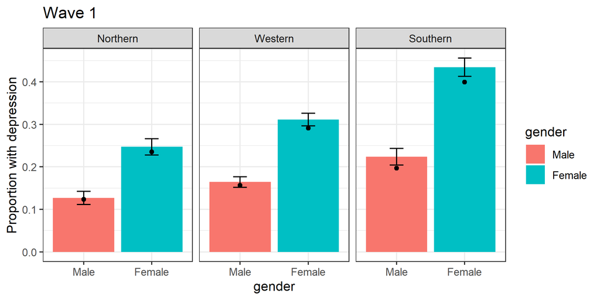

```r
include_graphics("out/prev.w1.png")
```

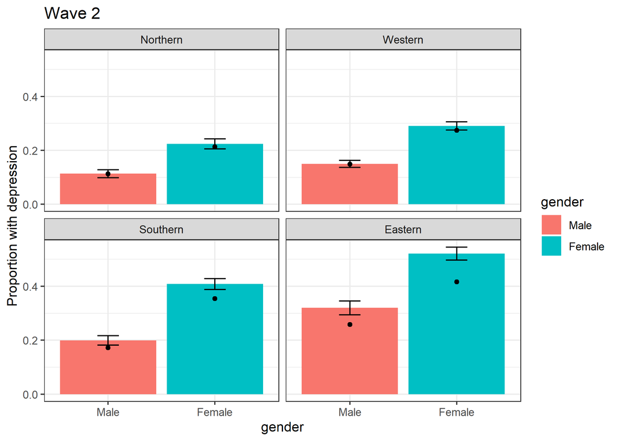

```r
include_graphics("out/prev.w2.png")
```

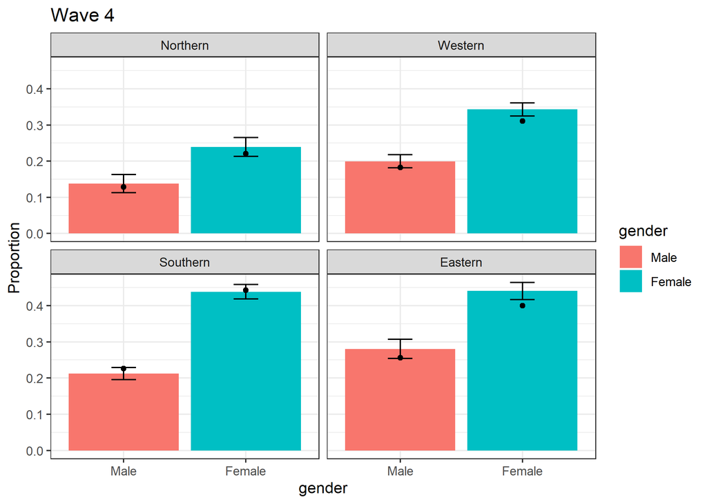

```r
include_graphics("out/prev.w4.png")
```

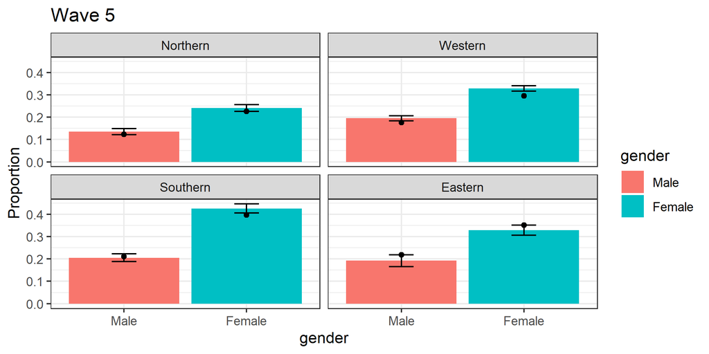

```r
include_graphics("out/prev.w5.png")
```

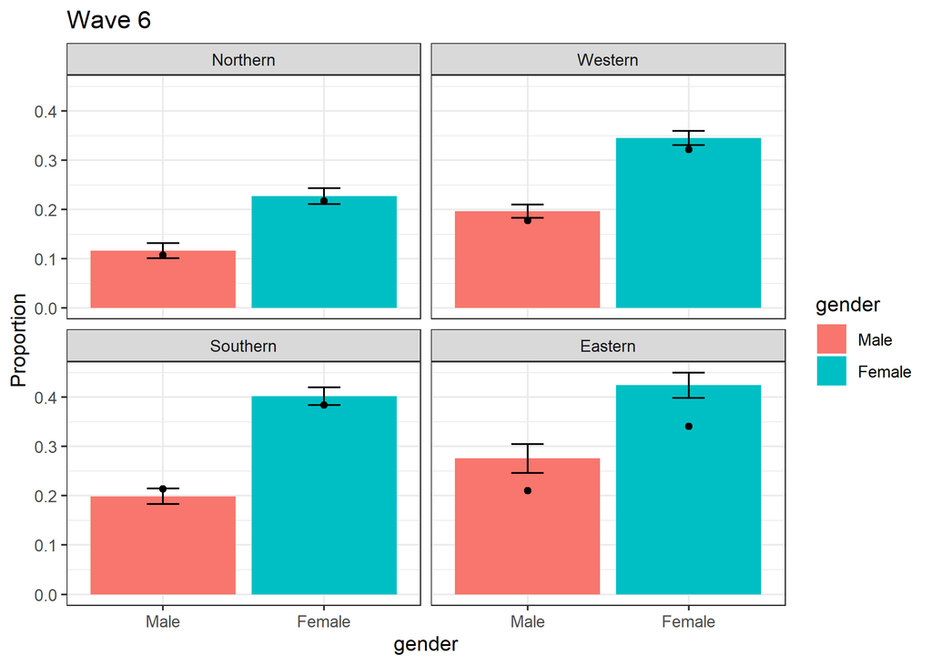

```r
include_graphics("out/prev.w6.png")
```

```r
f.table <- function(df)
{
  a <- paste0(round(df[,3],2), " (", round(df[,4],2),"-", round(df[,5],2), ") ")
  b <- paste0(round(df[,6],2), " (", round(df[,7],2),"-", round(df[,8],2), ") ")
  cbind.data.frame(df[,1:2], UW = a, WD= b)
}


f.table2 <- function(df)
{
  a <- paste0(" ", round(df[,1],2), " (", round(df[,2],2),"-", round(df[,3],2),    ") ", "; P=", ifelse(df[,4]>0.01, round(df[,4], 2), "<0.01"),  "  ")
  b <- paste0(" ", round(df[,5],2), " (", round(df[,6],2),"-", round(df[,7],2),  ") ",  "; P=", ifelse(df[,8]>0.01, round(df[,4], 2), "<0.01") , "  ")
  df1<-cbind.data.frame(`UW OR` = a, `WD OR`= b)
  dimnames(df1)[[1]] <- dimnames(df)[[1]]
  df1
 }
kable(f.table(tab.w1[,-c(9:11)]), digits=2, caption="Wave 1 - Prevalence of depression and 95% CI stratified by gender and region; UW: unweighted, W: weighted using calibration weights, D: using sampling design.")
```

Wave 1 - Prevalence of depression and 95% CI stratified by gender and region; UW: unweighted, W: weighted using calibration weights, D: using sampling design.

| Region | Gender | UW | WD |
| --- | --- | --- | --- |
| Northern | Male | 0.12 (0.11-0.14) | 0.13 (0.11-0.14) |
| Northern | Female | 0.24 (0.22-0.25) | 0.25 (0.23-0.27) |
| Western | Male | 0.16 (0.15-0.17) | 0.16 (0.15-0.18) |
| Western | Female | 0.29 (0.28-0.3) | 0.31 (0.29-0.33) |
| Southern | Male | 0.2 (0.18-0.21) | 0.22 (0.2-0.25) |
| Southern | Female | 0.4 (0.38-0.42) | 0.43 (0.41-0.46) |

```r
kable(f.table(tab.w2[,-c(9:11)]), digits=2, caption="Wave 2 - Prevalence of depression and 95% CI stratified by gender and region; UW: unweighted, W: weighted using calibration weights, D: using sampling design.")
```

Wave 2 - Prevalence of depression and 95% CI stratified by gender and region; UW: unweighted, W: weighted using calibration weights, D: using sampling design.

| Region | Gender | UW | WD |
| --- | --- | --- | --- |
| Northern | Male | 0.11 (0.1-0.13) | 0.11 (0.1-0.13) |
| Northern | Female | 0.21 (0.2-0.23) | 0.22 (0.21-0.24) |
| Western | Male | 0.15 (0.14-0.16) | 0.15 (0.14-0.16) |
| Western | Female | 0.27 (0.26-0.28) | 0.29 (0.27-0.31) |
| Southern | Male | 0.17 (0.16-0.18) | 0.2 (0.18-0.22) |
| Southern | Female | 0.35 (0.34-0.37) | 0.41 (0.38-0.43) |
| Eastern | Male | 0.26 (0.24-0.28) | 0.32 (0.29-0.35) |
| Eastern | Female | 0.42 (0.4-0.43) | 0.52 (0.49-0.55) |

```r
kable(f.table(tab.w4[,-c(9:11)]), digits=2, caption="Wave 4 - Prevalence of depression and 95% CI stratified by gender and region; UW: unweighted, W: weighted using calibration weights, D: using sampling design.")
```

Wave 4 - Prevalence of depression and 95% CI stratified by gender and region; UW: unweighted, W: weighted using calibration weights, D: using sampling design.

| Region | Gender | UW | WD |
| --- | --- | --- | --- |
| Northern | Male | 0.13 (0.11-0.14) | 0.14 (0.11-0.16) |
| Northern | Female | 0.22 (0.2-0.24) | 0.24 (0.21-0.27) |
| Western | Male | 0.18 (0.18-0.19) | 0.2 (0.18-0.22) |
| Western | Female | 0.31 (0.3-0.32) | 0.34 (0.32-0.36) |
| Southern | Male | 0.23 (0.21-0.24) | 0.21 (0.19-0.23) |
| Southern | Female | 0.44 (0.43-0.46) | 0.44 (0.41-0.46) |
| Eastern | Male | 0.26 (0.25-0.27) | 0.28 (0.25-0.31) |
| Eastern | Female | 0.4 (0.39-0.41) | 0.44 (0.42-0.47) |

```r
kable(f.table(tab.w5[,-c(9:11)]), digits=2, caption="Wave 5 - Prevalence of depression and 95% CI stratified by gender and region; UW: unweighted, W: weighted using calibration weights, D: using sampling design.")
```

Wave 5 - Prevalence of depression and 95% CI stratified by gender and region; UW: unweighted, W: weighted using calibration weights, D: using sampling design.

| Region | Gender | UW | WD |
| --- | --- | --- | --- |
| Northern | Male | 0.12 (0.11-0.13) | 0.14 (0.12-0.15) |
| Northern | Female | 0.23 (0.21-0.24) | 0.24 (0.23-0.26) |
| Western | Male | 0.18 (0.17-0.18) | 0.2 (0.18-0.21) |
| Western | Female | 0.3 (0.29-0.3) | 0.33 (0.32-0.34) |
| Southern | Male | 0.21 (0.2-0.22) | 0.21 (0.19-0.23) |
| Southern | Female | 0.4 (0.38-0.41) | 0.43 (0.4-0.45) |
| Eastern | Male | 0.22 (0.21-0.23) | 0.19 (0.17-0.22) |
| Eastern | Female | 0.35 (0.34-0.36) | 0.33 (0.3-0.35) |

```r
kable(f.table(tab.w6[,-c(9:11)]) , digits=2, caption="Wave 6 - Prevalence of depression and 95% CI stratified by gender and region; UW: unweighted, W: weighted using calibration weights, D: using sampling design.")
```

Wave 6 - Prevalence of depression and 95% CI stratified by gender and region; UW: unweighted, W: weighted using calibration weights, D: using sampling design.

| Region | Gender | UW | WD |
| --- | --- | --- | --- |
| Northern | Male | 0.11 (0.1-0.12) | 0.12 (0.1-0.13) |
| Northern | Female | 0.22 (0.2-0.23) | 0.23 (0.21-0.24) |
| Western | Male | 0.18 (0.17-0.19) | 0.2 (0.18-0.21) |
| Western | Female | 0.32 (0.31-0.33) | 0.35 (0.33-0.36) |
| Southern | Male | 0.21 (0.2-0.22) | 0.2 (0.18-0.22) |
| Southern | Female | 0.38 (0.37-0.39) | 0.4 (0.38-0.42) |
| Eastern | Male | 0.21 (0.2-0.22) | 0.28 (0.24-0.31) |
| Eastern | Female | 0.34 (0.33-0.35) | 0.42 (0.4-0.45) |

#### 1.1.5.2 Results from regression models

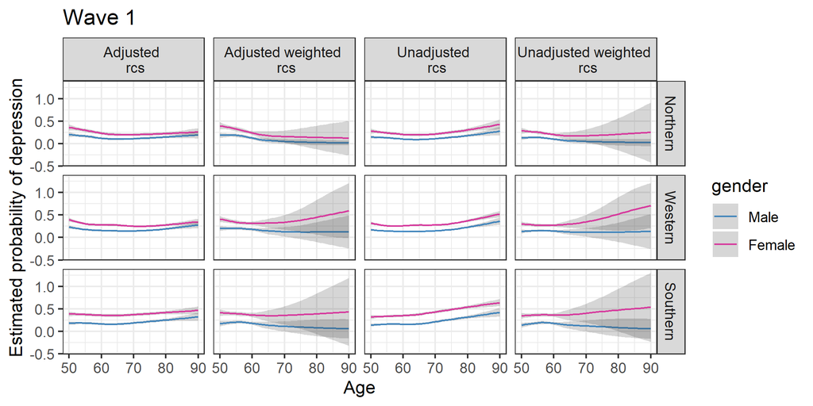

```r
include_graphics("out/modCI.w1.png")
```

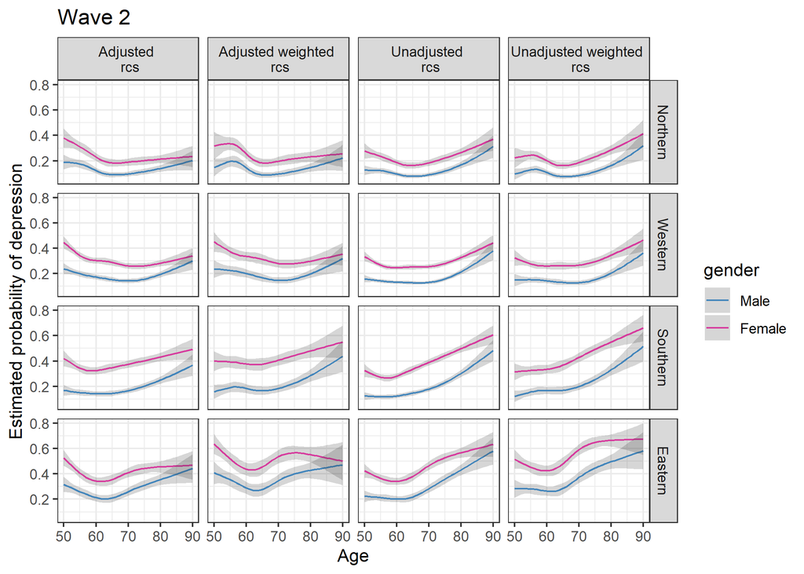

```r
include_graphics("out/modCI.w2.png")
```

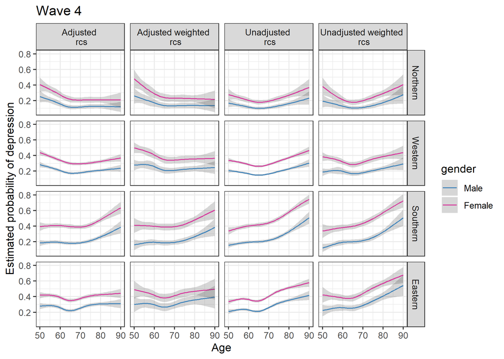

```r
include_graphics("out/modCI.w4.png")
```

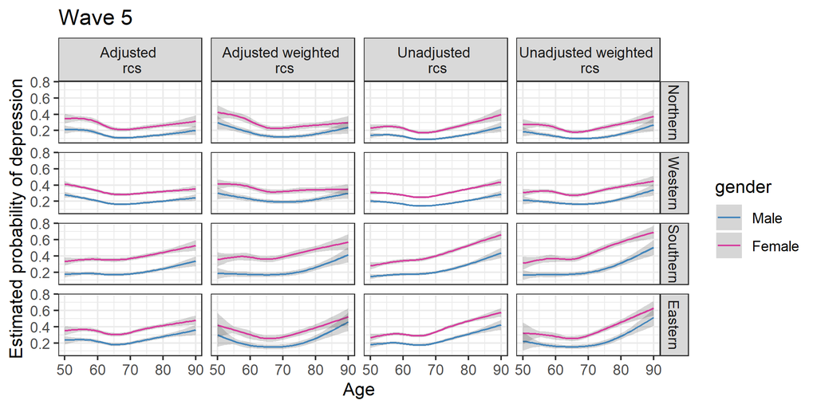

```r
include_graphics("out/modCI.w5.png")
```

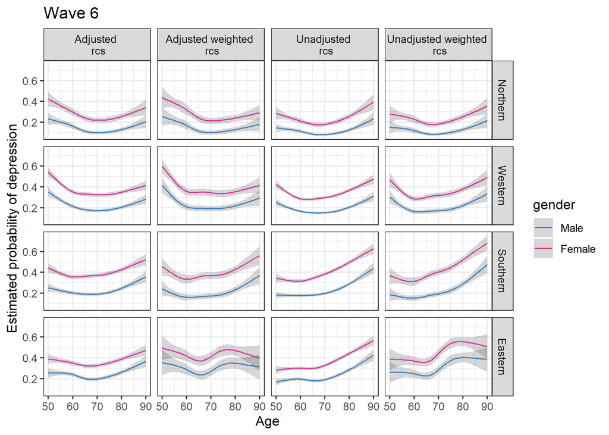

```r
include_graphics("out/modCI.w6.png")
```

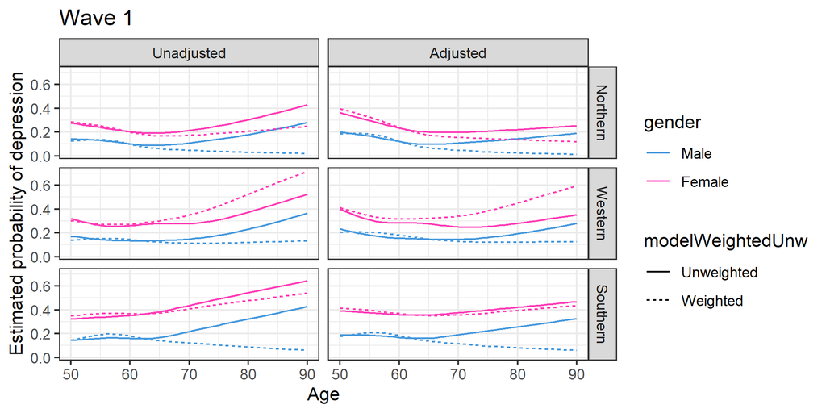

```r
include_graphics("out/mod.w1.png")
```

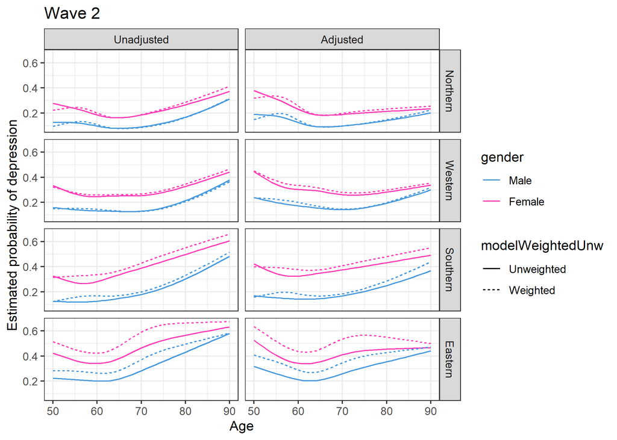

```r
include_graphics("out/mod.w2.png")
```

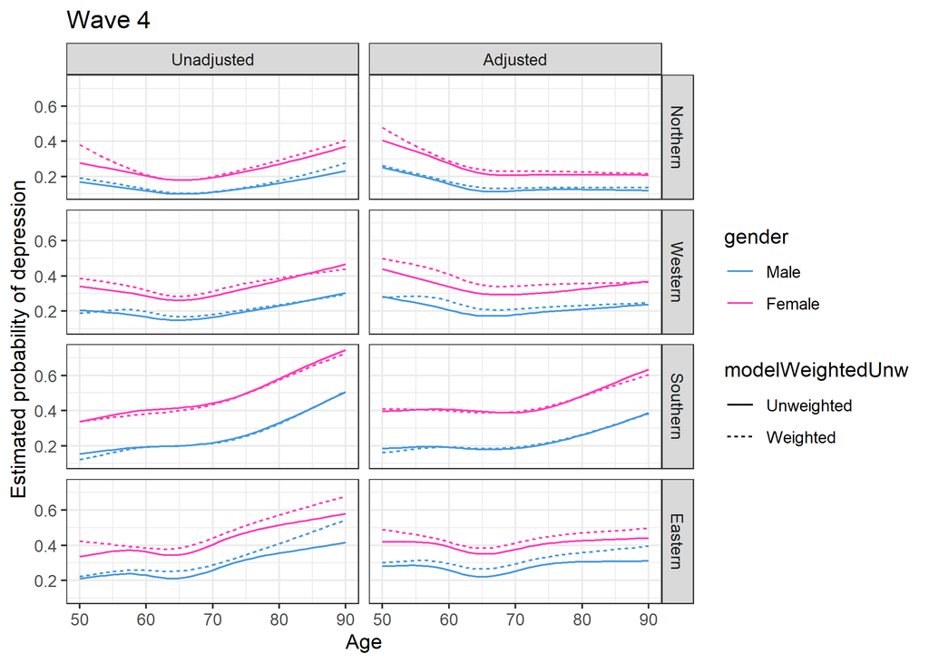

```r
include_graphics("out/mod.w4.png")
```

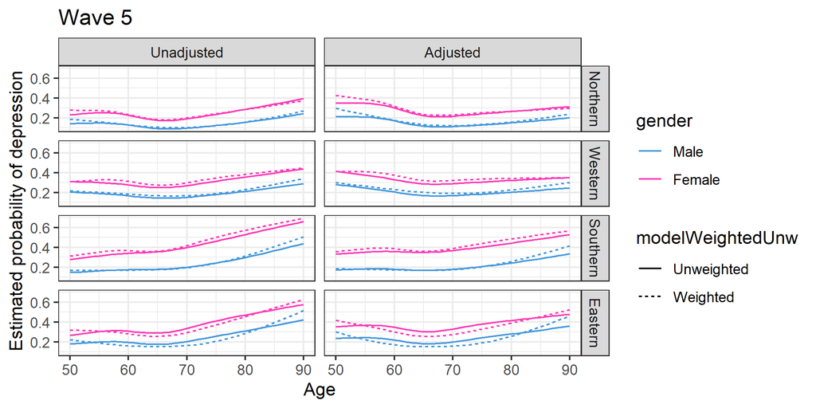

```r
include_graphics("out/mod.w5.png")
```

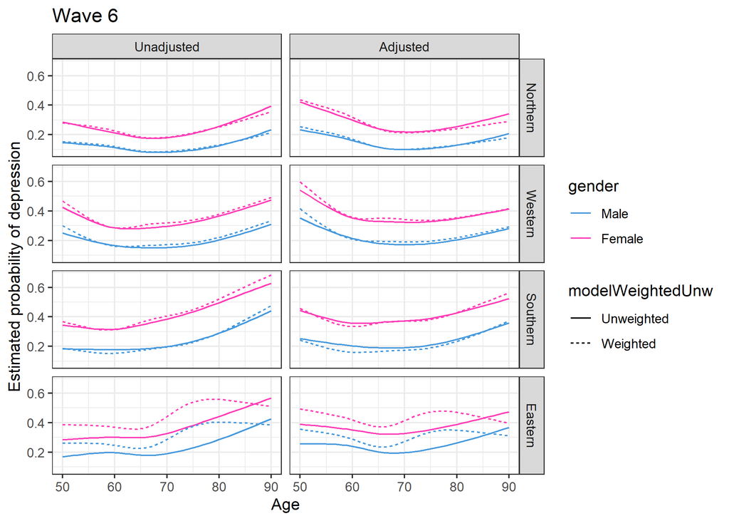

```r
include_graphics("out/mod.w6.png")
```

```r
kable(f.table2(OR.w1[,-c(9:11)]), digits=2, caption="Wave 1 - OR.")
```

Wave 1 - OR.

|  | UW OR | WD OR |
| --- | --- | --- |
| bmi_imp | 1 (1-1.01) ; P=0.45 | 1 (0.99-1.01) ; P=0.45 |
| education_impMedium | 0.75 (0.69-0.8) ; P=<0.01 | 0.67 (0.6-0.75) ; P=<0.01 |
| education_impHigh | 0.64 (0.58-0.7) ; P=<0.01 | 0.54 (0.47-0.62) ; P=<0.01 |
| education_impOther | 1.23 (0.88-1.71) ; P=0.22 | 0.94 (0.61-1.45) ; P=0.22 |
| cusmoke_impYes | 1.16 (1.07-1.26) ; P=<0.01 | 1.13 (1.01-1.27) ; P=0 |
| dis_chronic_pres1 | 1.46 (1.36-1.57) ; P=<0.01 | 1.51 (1.36-1.67) ; P=<0.01 |
| dis_chronic_pres2+ | 2.44 (2.24-2.67) ; P=<0.01 | 2.49 (2.15-2.88) ; P=<0.01 |
| pa_vigOnce a week | 1 (0.9-1.11) ; P=0.99 | 1.01 (0.86-1.17) ; P=0.99 |
| pa_vigOne to three times a month | 1.1 (0.98-1.24) ; P=0.1 | 1.19 (1.01-1.4) ; P=0.1 |
| pa_vigHardly ever, or never | 1.77 (1.64-1.91) ; P=<0.01 | 1.74 (1.56-1.95) ; P=<0.01 |
| living_arrangementLiving alone | 1.47 (1.37-1.58) ; P=<0.01 | 1.4 (1.27-1.54) ; P=<0.01 |

```r
kable(f.table2(OR.w2[,-c(9:11)]), digits=2, caption="Wave 2 - OR ")
```

Wave 2 - OR

|  | UW OR | WD OR |
| --- | --- | --- |
| bmi_imp | 0.99 (0.99-1) ; P=0.07 | 0.99 (0.98-1) ; P=0.07 |
| education_impMedium | 0.75 (0.7-0.8) ; P=<0.01 | 0.69 (0.62-0.77) ; P=<0.01 |
| education_impHigh | 0.64 (0.58-0.7) ; P=<0.01 | 0.59 (0.51-0.67) ; P=<0.01 |
| education_impOther | 1.27 (0.91-1.76) ; P=0.16 | 1.22 (0.78-1.91) ; P=0.16 |
| cusmoke_impYes | 1.2 (1.11-1.29) ; P=<0.01 | 1.13 (1.02-1.26) ; P=0 |
| dis_chronic_pres1 | 1.43 (1.34-1.53) ; P=<0.01 | 1.38 (1.26-1.51) ; P=<0.01 |
| dis_chronic_pres2+ | 2.48 (2.3-2.69) ; P=<0.01 | 2.4 (2.14-2.7) ; P=<0.01 |
| pa_vigOnce a week | 1 (0.91-1.11) ; P=0.94 | 0.97 (0.83-1.13) ; P=0.94 |
| pa_vigOne to three times a month | 1.03 (0.93-1.15) ; P=0.58 | 1.06 (0.89-1.25) ; P=0.58 |
| pa_vigHardly ever, or never | 1.94 (1.81-2.08) ; P=<0.01 | 1.92 (1.71-2.15) ; P=<0.01 |
| living_arrangementLiving alone | 1.19 (1.11-1.26) ; P=<0.01 | 1.28 (1.17-1.41) ; P=<0.01 |

```r
kable(f.table2(OR.w4[,-c(9:11)]), digits=2, caption="Wave 4 - OR ")
```

Wave 4 - OR

|  | UW OR | WD OR |
| --- | --- | --- |
| bmi_imp | 1 (0.99-1) ; P=0.42 | 0.99 (0.98-1) ; P=0.42 |
| education_impMedium | 0.74 (0.7-0.77) ; P=<0.01 | 0.7 (0.63-0.78) ; P=<0.01 |
| education_impHigh | 0.64 (0.6-0.68) ; P=<0.01 | 0.57 (0.49-0.66) ; P=<0.01 |
| education_impOther | 0.84 (0.63-1.12) ; P=0.23 | 1.32 (0.85-2.05) ; P=0.23 |
| cusmoke_impYes | 1.2 (1.14-1.27) ; P=<0.01 | 1.21 (1.07-1.38) ; P=<0.01 |
| dis_chronic_pres1 | 1.4 (1.33-1.47) ; P=<0.01 | 1.36 (1.22-1.52) ; P=<0.01 |
| dis_chronic_pres2+ | 2.47 (2.34-2.62) ; P=<0.01 | 2.44 (2.17-2.74) ; P=<0.01 |
| pa_vigOnce a week | 1.05 (0.98-1.12) ; P=0.19 | 0.97 (0.83-1.15) ; P=0.19 |
| pa_vigOne to three times a month | 1.1 (1.02-1.19) ; P=0.02 | 1.07 (0.9-1.27) ; P=0.02 |
| pa_vigHardly ever, or never | 1.79 (1.7-1.88) ; P=<0.01 | 1.77 (1.59-1.97) ; P=<0.01 |
| living_arrangementLiving alone | 1.2 (1.15-1.26) ; P=<0.01 | 1.17 (1.07-1.29) ; P=<0.01 |

```r
kable(f.table2(OR.w5[,-c(9:11)]), digits=2, caption="Wave 5 - OR")
```

Wave 5 - OR

|  | UW OR | WD OR |
| --- | --- | --- |
| bmi_imp | 1 (1-1.01) ; P=0.24 | 1 (1-1.01) ; P=0.24 |
| education_impMedium | 0.77 (0.73-0.81) ; P=<0.01 | 0.75 (0.68-0.82) ; P=<0.01 |
| education_impHigh | 0.66 (0.62-0.7) ; P=<0.01 | 0.58 (0.52-0.66) ; P=<0.01 |
| education_impOther | 1.03 (0.75-1.4) ; P=0.87 | 1.11 (0.67-1.82) ; P=0.87 |
| cusmoke_impYes | 1.33 (1.26-1.4) ; P=<0.01 | 1.39 (1.27-1.53) ; P=<0.01 |
| dis_chronic_pres1 | 1.37 (1.3-1.43) ; P=<0.01 | 1.35 (1.25-1.47) ; P=<0.01 |
| dis_chronic_pres2+ | 2.32 (2.2-2.46) ; P=<0.01 | 2.3 (2.09-2.54) ; P=<0.01 |
| pa_vigOnce a week | 0.99 (0.93-1.06) ; P=0.86 | 0.92 (0.81-1.05) ; P=0.86 |
| pa_vigOne to three times a month | 1.12 (1.03-1.21) ; P=<0.01 | 1.11 (0.95-1.28) ; P=0.01 |
| pa_vigHardly ever, or never | 1.86 (1.77-1.95) ; P=<0.01 | 1.84 (1.69-2.01) ; P=<0.01 |
| living_arrangementLiving alone | 1.21 (1.16-1.26) ; P=<0.01 | 1.22 (1.12-1.31) ; P=<0.01 |

```r
kable(f.table2(OR.w6[,-c(9:11)]) , digits=2, caption="Wave 6 - OR")
```

Wave 6 - OR

|  | UW OR | WD OR |
| --- | --- | --- |
| bmi_imp | 1 (1-1.01) ; P=0.09 | 0.99 (0.99-1) ; P=0.09 |
| education_impMedium | 0.78 (0.74-0.81) ; P=<0.01 | 0.71 (0.65-0.78) ; P=<0.01 |
| education_impHigh | 0.67 (0.64-0.71) ; P=<0.01 | 0.57 (0.51-0.64) ; P=<0.01 |
| education_impOther | 0.94 (0.67-1.31) ; P=0.71 | 1.68 (0.99-2.87) ; P=0.71 |
| dis_chronic_pres1 | 1.35 (1.29-1.42) ; P=<0.01 | 1.49 (1.38-1.62) ; P=<0.01 |
| dis_chronic_pres2+ | 2.21 (2.09-2.33) ; P=<0.01 | 2.32 (2.1-2.57) ; P=<0.01 |
| pa_vigOnce a week | 1.13 (1.06-1.2) ; P=<0.01 | 1.09 (0.97-1.22) ; P=0 |
| pa_vigOne to three times a month | 1.3 (1.21-1.4) ; P=<0.01 | 1.31 (1.13-1.52) ; P=<0.01 |
| pa_vigHardly ever, or never | 1.82 (1.74-1.91) ; P=<0.01 | 1.68 (1.53-1.84) ; P=<0.01 |
| living_arrangementLiving alone | 1.15 (1.11-1.2) ; P=<0.01 | 1.19 (1.1-1.29) ; P=<0.01 |

### 1.1.6 Sensitivity analysis for wave 1

As we observed big differences between weighted and unweighthed analyses in Wave 1, we remove subjects with large weights and refit the models.

```r
#retrieval of weights from wave 1
share.data.weights <- f_readRShare(
  datadir = "sharedata",
  waves = 1,
  modules = "gv_weights",
  modules.wX = NULL  ,
  countries = NULL,
  variables.in.modules = NULL,
  keep.module.name.in.vars = FALSE,
  verbose = FALSE
)$df.w



# obtain only data from wave 1 from those used to develop the models that include all waves
share.data.w1 <- filter(share.data.first.interview, Wave=="Wave 1")

# join with variable data
share.data.w1 <- left_join(share.data.weights[,c("mergeid", "dw_w1", "cciw_w1", "subsample", "stratum1", "stratum2", "psu", "ssu")], share.data.w1,  by="mergeid")

# filter out the observations with missing weights
share.data.w1  <- filter(share.data.w1, !is.na(cciw_w1))


#dropping the participants from Israel
share.data.w1  <- filter(share.data.w1, !is.na(age_int))

#dropping unused levels
share.data.w1 <- droplevels(share.data.w1)
```

```r
# assign weights equal to 1 to all participants in an additional variable to obtain unweighted estimates
share.data.w1$wAll1 <- 1


# setting to missing the strata and psu values that are empty
share.data.w1$stratum1[share.data.w1$stratum1==""] <- NA
share.data.w1$psu[share.data.w1$psu==""] <- NA
# number of missing psu
num.na.psu <- sum(is.na(share.data.w1$psu))
share.data.w1$psu <- as.numeric(share.data.w1$psu)

# using constant values for strata within country, all different values of psu for countries that did not have them in the design
share.data.w1$stratum1[is.na(share.data.w1$stratum1)] <- paste(share.data.w1$country[is.na(share.data.w1$stratum1)], "fake stratum")
share.data.w1$psu[is.na(share.data.w1$psu)] <- c((10^9+1) :  (10^9+num.na.psu))


# specify the sampling design
dstrat <- survey::svydesign(id=~psu,strata=~stratum1, weights=~ cciw_w1,
data = share.data.w1, nest=TRUE)

# id=∼psu specifies sampling at primary sampling unit.
# stratum1 is a factor variable for stratum used for sampling, usually geographical units
# share.data.w1 is the data frame with all the data.
# cciw_w1 contains calibrated sampling weights

# remove the participants not used in the analysis - removed because of missing data or exclusion criteria
dstrat <- subset(dstrat, !is.na(eurodcat_imp))
```

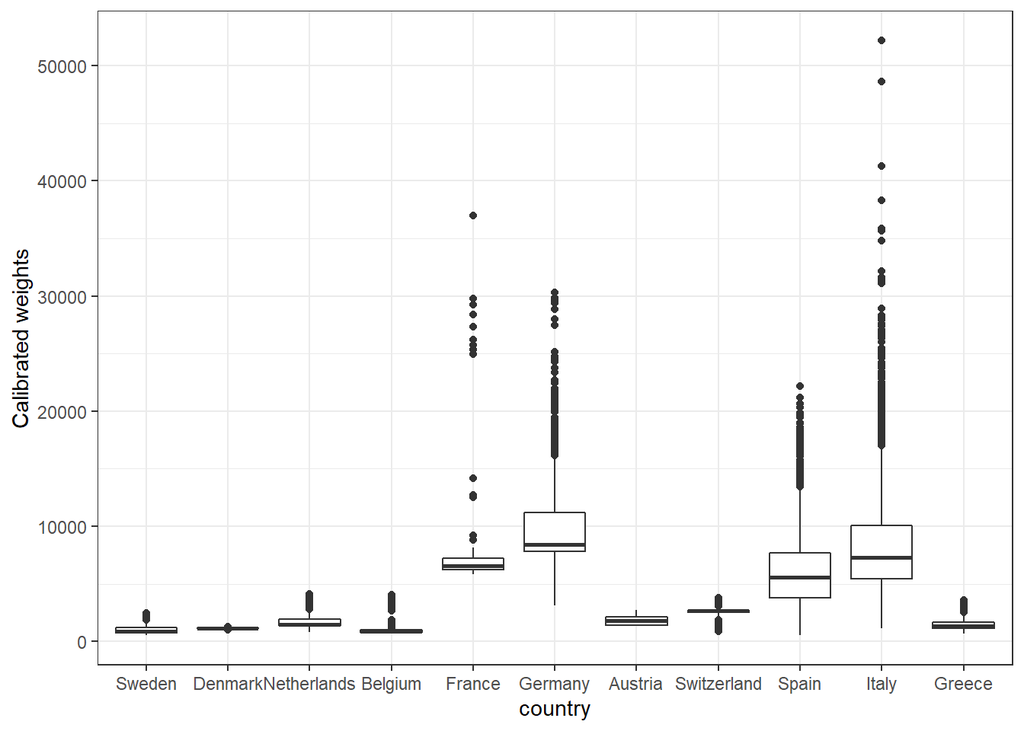

```r
ggplot(share.data.w1, aes(country, cciw_w1)) +  geom_boxplot() + theme_bw() + labs(y="Calibrated weights")
```

As expected, the largest weights are associated to the largest countries. We decided to remove the observations with calibrated weight above 20000, which is a value in the tail of the distributions also for large countries. Overall, we removed n= 206 observations (0.8%) .

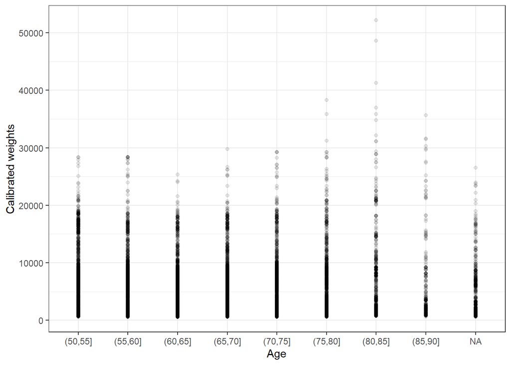

```r
ggplot(share.data.w1, aes(cut(age_int,breaks = seq(50, 95, by=5)) , cciw_w1)) +  geom_point(alpha=.1) + theme_bw() + labs(y="Calibrated weights", x="Age")
```

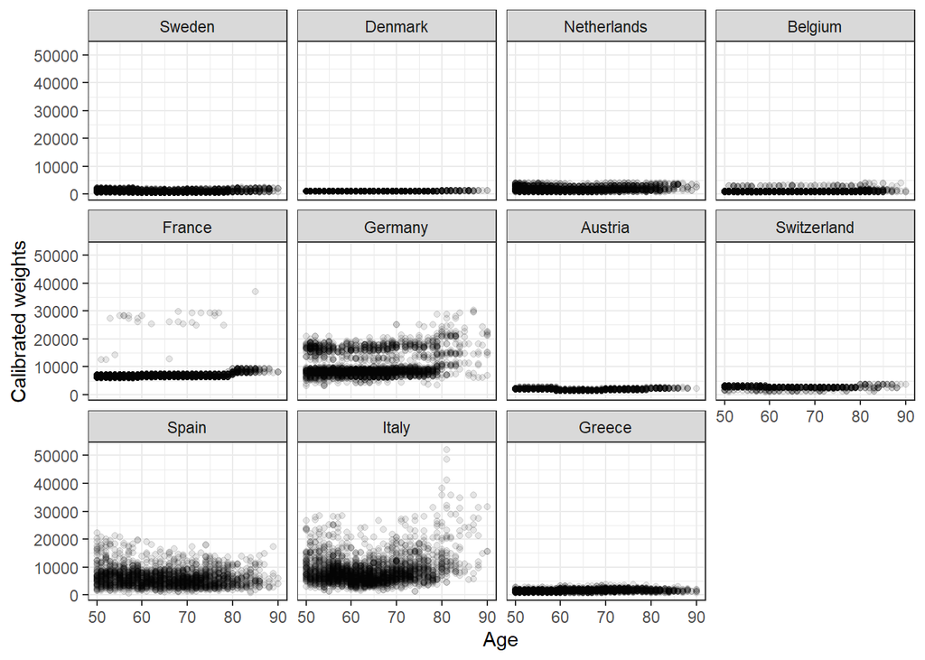

```r
ggplot(share.data.w1, aes(age_int, cciw_w1)) +  geom_point(alpha=.1) + theme_bw() + labs(y="Calibrated weights", x="Age") + facet_wrap(country~.)
```

There is no clear association between age and weights, in Italy large weights were mode common among older participants, in Spain among younger.

```r
# specify the sampling design
dstrat <- survey::svydesign(id=~psu,strata=~stratum1, weights=~ cciw_w1,
data = share.data.w1, nest=TRUE)

# id=∼psu specifies sampling at primary sampling unit.
# stratum1 is a factor variable for stratum used for sampling, usually geographical units
# share.data.w1 is the data frame with all the data.
# cciw_w1 contains calibrated sampling weights

# remove the participants not used in the analysis - removed because of missing data or exclusion criteria
dstrat <- subset(dstrat, !is.na(eurodcat_imp) & cciw_w1<=20000)
```

#### 1.1.6.1 Unadjusted models - weighted models and comparsion with unweighted

```r
share.data.w1.sens <- filter(share.data.w1, cciw_w1<=20000)


my.mod <- glm(eurodcat_imp ~ rcs(age_int_stand) + gender + region +
                       rcs(age_int_stand):region + rcs(age_int_stand):gender + gender:region ,
                                             data=share.data.w1.sens, family="binomial",  x=TRUE, y=TRUE)

#save the spline terms in the complete data set for further use
share.data.w1.sens <- share.data.w1.sens %>% mutate(age1 = my.mod$x[,2],
                                                                    age2 = my.mod$x[,3],
                                                                    age3 = my.mod$x[,4],
                                                                    age4 = my.mod$x[,5])


# retrieve the location of knots used and assign them to Knots variable
Knots <- Hmisc::rcspline.eval(x = share.data.w1$age_int_stand, nk = 5, knots.only = TRUE)

#reproduces the spline values for age, expands for each integer value from 50 to 90
age = rcspline.eval(c(50:90)-50, knots=Knots)
age <- cbind.data.frame(age1=c(50:90)-50, age )
dimnames(age)[[2]] <- c("age1", "age2", "age3", "age4")






if(!is.null(my.mod$na.action)){
my.mod2 <- glm(eurodcat_imp ~ age1 + age2 + age3 + age4 + gender + region +
                      age1:region + age2:region + age3:region + age4:region +
                       age1:gender + age2:gender + age3:gender + age4:gender +
                       gender:region ,
                        data=share.data.w1.sens[-my.mod$na.action,], family="binomial",  x=TRUE, y=TRUE)} else {
 my.mod2 <- glm(eurodcat_imp ~ age1 + age2 + age3 + age4 + gender + region +
                      age1:region + age2:region + age3:region + age4:region +
                       age1:gender + age2:gender + age3:gender + age4:gender +
                       gender:region ,
                        data=share.data.w1.sens, family="binomial",  x=TRUE, y=TRUE)
}





#derive the data.frame containing the levels of the covariatee, where the probabilities of depression estimated by the model will be derived
data.grid <- expand.grid(age1=age[,1], gender=levels(share.data.w1.sens$gender), region=levels(share.data.w1.sens$region))
data.grid <- left_join(data.grid, age, by="age1" )

#data.grid <- filter(data.grid, is.element(region, c("Austria", "Spain", "Italy", "France", "Belgium", "Israel")))
data.grid.region <- data.grid


#defining also data grid for countries
data.grid.region <- expand.grid(age1=age[,1], gender=levels(share.data.w1.sens$gender), region=levels(share.data.w1.sens$region))
data.grid.region <- left_join(data.grid.region, age, by="age1" )




#derive the predicted probabilities
my.pred <- predict(my.mod2, newdata=data.grid, se.fit = TRUE, type="response")

#join the levels of the covariates and the predicted probabilities
my.pred.all <- cbind.data.frame(data.grid, my.pred)

#saving the estimates from the 2-way models
pred.age_unadjusted_region_rcs <- my.pred.all
```

```r
ggplot(my.pred.all, aes(age1+50, fit, color=gender)) + geom_line() + facet_wrap(region~., ncol=5) + labs(x="Age", y="Estimated probability of depression") + scale_color_manual(values=c("#4699dd","#ff3db7" )) + ggtitle("Unadjusted - (gender, region, rcs(age))") +
  geom_ribbon(aes(ymin = fit - 1.96*se.fit, ymax = fit + 1.96*se.fit), alpha = 0.2, linetype=0) +  theme_bw()


#my.pred.all %>% left_join(select(filter(share.data.w1, cciw_w1<20000), starts_with("region")), by="region") %>% ggplot(aes(age1, fit, #color=gender))+ geom_point() + facet_grid(.~regionGroup) + labs(x="Age", y="Estimated probability of depression") + #scale_color_manual(values=c("#4699dd","#ff3db7" ))


anova(my.mod, test="Chi")
```

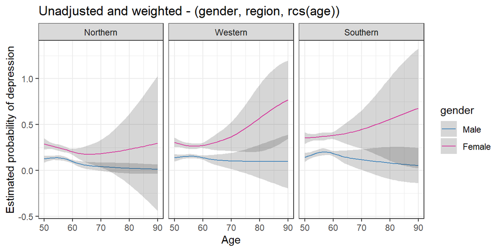

```r
 my.mod.w <- svyglm(eurodcat_imp ~ age1 + age2 + age3 + age4 + gender + region +
                      age1:region + age2:region + age3:region + age4:region +
                       age1:gender + age2:gender + age3:gender + age4:gender +
                       gender:region ,
                        design=dstrat, family="binomial",  x=TRUE, y=TRUE)




#derive the predicted probabilities
my.pred <- predict(my.mod.w, newdata=data.grid, se.fit = TRUE, type="response")
#join the levels of the covariates and the predicted probabilities
my.pred.all <- cbind.data.frame(data.grid, my.pred)

my.pred.all <- pred.age_unadjusted_region_rcs_w<- rename(my.pred.all, fit=response, se.fit = SE)
pred.age_unadjusted_region_rcs_w <- mutate(pred.age_unadjusted_region_rcs_w, residual.scale = 1)

pred.age_all <- rbind.data.frame(pred.age_unadjusted_region_rcs,pred.age_unadjusted_region_rcs_w)
pred.age_all <- mutate(pred.age_all, model=c(rep("Unadjusted \n rcs", nrow(pred.age_unadjusted_region_rcs)), rep("Unadjusted weighted \n rcs", nrow(pred.age_unadjusted_region_rcs))))

#saving the estimates from the 2-way models
pred.age_unadjusted_region_rcs <- my.pred.all




ggplot(my.pred.all, aes(age1+50, fit, color=gender)) + geom_line() + facet_wrap(region~., ncol=5) + labs(x="Age", y="Estimated probability of depression") + scale_color_manual(values=c("#4699dd","#ff3db7" )) + ggtitle("Unadjusted and weighted - (gender, region, rcs(age))") +
  geom_ribbon(aes(ymin = fit - 1.96*se.fit, ymax = fit + 1.96*se.fit), alpha = 0.2, linetype=0) +  theme_bw()
```

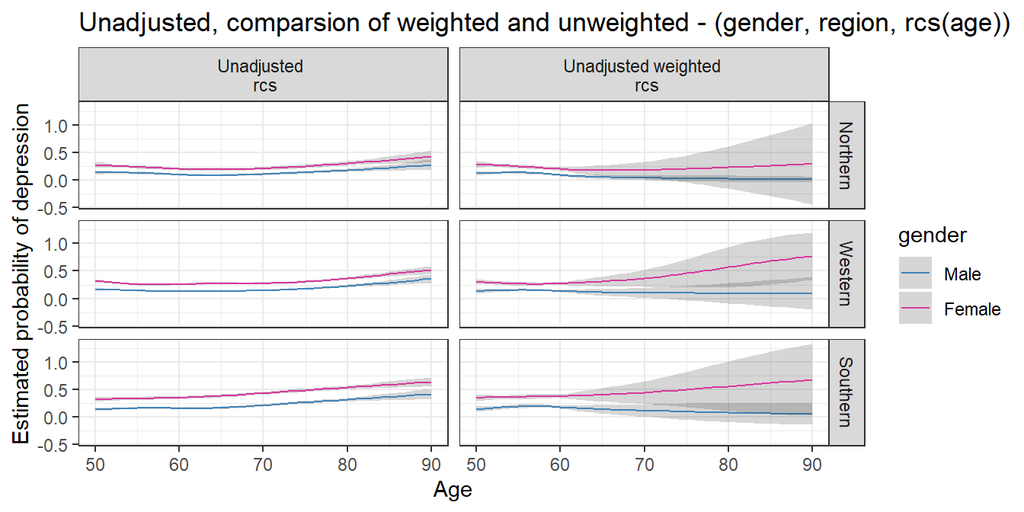

```r
#my.pred.all %>% left_join(select(share.data.w1, starts_with("region")), by="region") %>% ggplot(aes(age1, fit, #color=gender))+ geom_point() + facet_grid(.~regionGroup) + labs(x="Age", y="Estimated probability of depression") + #scale_color_manual(values=c("#4699dd","#ff3db7" ))


#anova(my.mod.w, test="Chi")



ggplot(pred.age_all, aes(age1+50, fit, color=gender)) + geom_line() + facet_grid(region~model) + labs(x="Age", y="Estimated probability of depression") + scale_color_manual(values=c("#4699dd","#ff3db7" )) + ggtitle("Unadjusted, comparsion of weighted and unweighted - (gender, region, rcs(age))") +
  geom_ribbon(aes(ymin = fit - 1.96*se.fit, ymax = fit + 1.96*se.fit), alpha = 0.2, linetype=0) +  theme_bw()
```

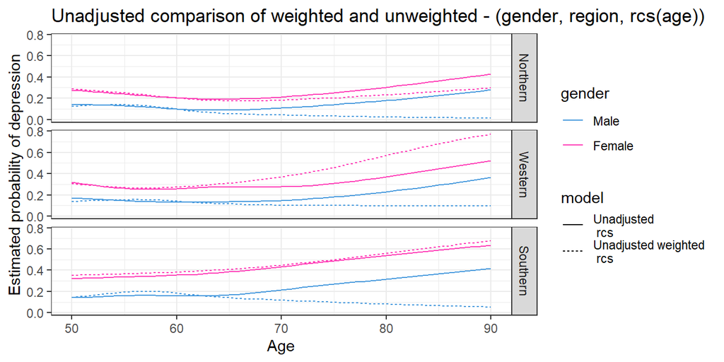

```r
ggplot(pred.age_all, aes(age1+50, fit, color=gender)) + geom_line(aes(linetype=model)) + facet_grid(region~.) + labs(x="Age", y="Estimated probability of depression") + scale_color_manual(values=c("#4699dd","#ff3db7" )) + ggtitle("Unadjusted comparison of weighted and unweighted - (gender, region, rcs(age))") +
 # geom_ribbon(aes(ymin = fit - 1.96*se.fit, ymax = fit + 1.96*se.fit), alpha = 0.2, linetype=0) +
  theme_bw()
```

#### 1.1.6.2 Adjusted models - weighted models and comparsion with unweighted

```r
my.mod2  <- glm(
  eurodcat_imp ~
    age1 + age2 + age3 + age4 + gender + region +
    bmi_imp + education_imp + #cusmoke_imp +
    dis_chronic_pres +
    pa_vig + living_arrangement +
    age1:region + age2:region + age3:region + age4:region +
    age1:gender + age2:gender + age3:gender + age4:gender +
    gender:region,
  data = share.data.w1,
  family = "binomial",
  x = TRUE,
  y = TRUE
)



my.mod1  <- glm(
  eurodcat_imp ~
    rcspline.eval(age_int_stand, knots=Knots, inclx = TRUE) + gender + region +
    bmi_imp + education_imp + #cusmoke_imp +
    dis_chronic_pres +
    pa_vig + living_arrangement +
     rcspline.eval(age_int_stand, knots=Knots, inclx = TRUE):region +
     rcspline.eval(age_int_stand, knots=Knots, inclx = TRUE):gender +
    gender:region,
  data = share.data.w1,
  family = "binomial",
  x = TRUE,
  y = TRUE
)



data.grid.adj <- expand.grid(age1=unique(share.data.w1$age1), gender=levels(share.data.w1$gender), region=levels(share.data.w1$region),
                         #overall mean
                         #bmi_10 = mean(share.data.w1$bmi_imp, na.rm=TRUE),

                      education_imp ="Low", cusmoke_imp="No",  dis_chronic_pres="0",
                        pa_vig = "Hardly ever, or never" ,  living_arrangement="Living with partner"
                         )


#using median bmi, separate evaluation by gender

data.grid.adj <- left_join(data.grid.adj,
          share.data.w1 %>% group_by(gender) %>%
            #rename(age1 = age_int_stand) %>%
            summarise(bmi_imp=median(bmi_imp, na.rm=TRUE)),
           by=c("gender"))

data.grid.adj <- left_join(data.grid.adj, age, by="age1")
data.grid.adj.region <- data.grid.adj



#defining also data grid for countries
data.grid.adj.region <- expand.grid(age1=unique(share.data.w1$age1), gender=levels(share.data.w1$gender), region=levels(share.data.w1$region),
                         #overall mean
                         #bmi_10 = mean(share.data.w1$bmi_imp, na.rm=TRUE),

                      education_imp ="Low", cusmoke_imp="No",  dis_chronic_pres="0",
                        pa_vig = "Hardly ever, or never" ,  living_arrangement="Living with partner"
                         )
data.grid.adj.region <- left_join(data.grid.adj.region,
          share.data.w1 %>% group_by(gender) %>%
            #rename(age1 = age_int_stand) %>%
            summarise(bmi_imp=median(bmi_imp, na.rm=TRUE)),
           by=c("gender"))

data.grid.adj.region <- left_join(data.grid.adj.region, age, by="age1")


#derive the predicted probabilities
my.pred <- predict(my.mod2, newdata=data.grid.adj, se.fit = TRUE, type="response")

#join the levels of the covariates and the predicted probabilities
my.pred.all <- cbind.data.frame(data.grid.adj, my.pred)

#saving the estimates from the 2-way models
pred.age_adjusted_region_rcs <- my.pred.all


pred.age_adjusted_region_rcs <- mutate( pred.age_adjusted_region_rcs ,  "education_imp"=NA,      "cusmoke_imp"=NA  ,      "dis_chronic_pres"=NA  ,  "pa_vig" = NA,  "living_arrangement" = NA,  "bmi_imp" = NA,  "age2" = NA        ,       "age3" = NA ,              "age4" = NA    )
pred.age_adjusted_region_rcs<- mutate(pred.age_adjusted_region_rcs, model="Adjusted \n rcs")


pred.age_all <- mutate(pred.age_all,
                     "education_imp"=NA,      "cusmoke_imp"=NA  ,      "dis_chronic_pres"=NA  ,  "pa_vig" = NA,  "living_arrangement" = NA,  "bmi_imp" = NA )



pred.age_all <- rbind.data.frame(pred.age_all, pred.age_adjusted_region_rcs)
```

```r
ggplot(my.pred.all, aes(age1+50, fit, color=gender)) + geom_line() + facet_wrap(region~., ncol=5) + labs(x="Age", y="Estimated probability of depression") + scale_color_manual(values=c("#4699dd","#ff3db7" )) + ggtitle("Adjusted estimates (gender, region, rcs(age))") +
  geom_ribbon(aes(ymin = fit - 1.96*se.fit, ymax = fit + 1.96*se.fit), alpha = 0.2, linetype=0) +  theme_bw()


anova(my.mod1, test="Chi")
```

```r
#to display all the coefficients
#get.OR2(my.mod1)


#kable(get.OR2(my.mod1)[9:19,], digits=2, caption = "Estimated OR from the adjusted rcs model")
#kable(get.OR2(my.mod1)[10:20,], digits=2, caption = "Estimated OR from the adjusted rcs model",     format = "latex")


OR.uw <- get.OR2(my.mod1)[9:19,]
```

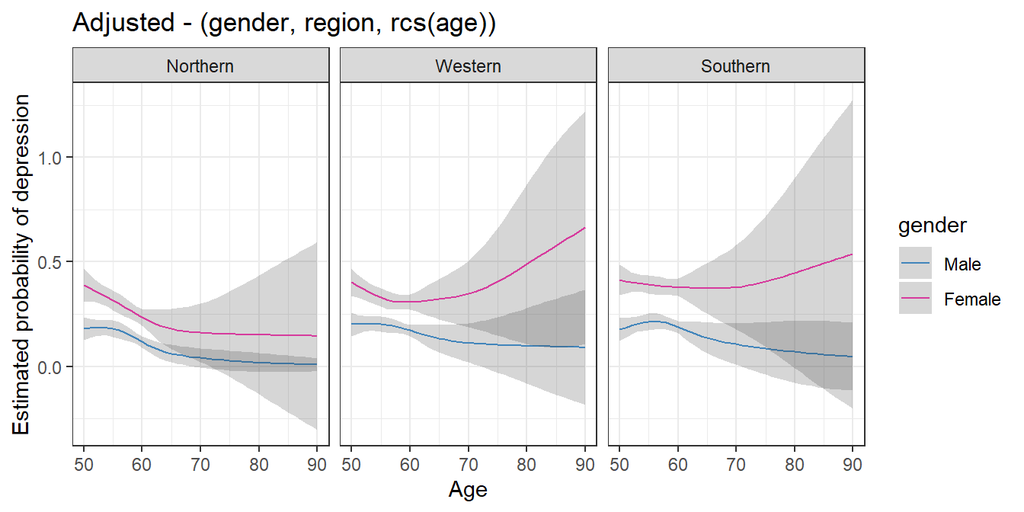

```r
#dstrat <- svydesign(id=~psu,strata=~stratum1, weights=~ cciw_w1,
#data=share.data.w1, nest=TRUE)


 my.mod.w <- svyglm(eurodcat_imp ~
    age1 + age2 + age3 + age4 + gender + region +
    bmi_imp + education_imp + cusmoke_imp + dis_chronic_pres +
    pa_vig + living_arrangement +
    age1:region + age2:region + age3:region + age4:region +
    age1:gender + age2:gender + age3:gender + age4:gender +
    gender:region,
                        design=dstrat, family="binomial",  x=TRUE, y=TRUE)




#derive the predicted probabilities
my.pred <- predict(my.mod.w, newdata=data.grid.adj.region, se.fit = TRUE, type="response")
#join the levels of the covariates and the predicted probabilities
my.pred.all <- cbind.data.frame(data.grid.adj.region, my.pred)

my.pred.all <- pred.age_unadjusted_region_rcs_w<- rename(my.pred.all, fit=response, se.fit = SE)
pred.age_adjusted_region_rcs_w <- mutate(pred.age_unadjusted_region_rcs_w, residual.scale = 1, model = "Adjusted weighted \n rcs")

pred.age_all <- rbind.data.frame(pred.age_all, pred.age_adjusted_region_rcs_w)

#saving the estimates from the 2-way models
pred.age_adjusted_region_rcs_w <- my.pred.all

ggplot(my.pred.all, aes(age1+50, fit, color=gender)) + geom_line() + facet_wrap(region~., ncol=5) + labs(x="Age", y="Estimated probability of depression") + scale_color_manual(values=c("#4699dd","#ff3db7" )) + ggtitle("Adjusted - (gender, region, rcs(age))") +
  geom_ribbon(aes(ymin = fit - 1.96*se.fit, ymax = fit + 1.96*se.fit), alpha = 0.2, linetype=0) +  theme_bw()
```

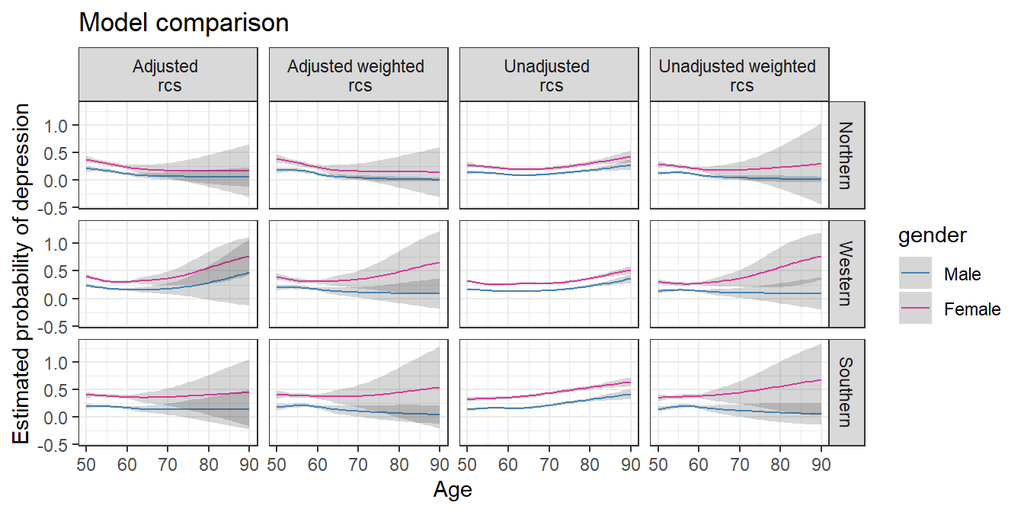

```r
#my.pred.all %>% left_join(select(share.data.w1, starts_with("region")), by="region") %>% ggplot(aes(age1, fit, #color=gender))+ geom_point() + facet_grid(.~regionGroup) + labs(x="Age", y="Estimated probability of depression") + #scale_color_manual(values=c("#4699dd","#ff3db7" ))


#anova(my.mod.w, test="Chi")

pred.age_all$modelAdjUnadj <- pred.age_all$modelWeightedUnw <- pred.age_all$model

level_key <- c(`Unadjusted \n rcs` = "Unadjusted", `Unadjusted weighted \n rcs` = "Unadjusted",
               `Adjusted \n rcs` = "Adjusted", `Adjusted weighted \n rcs` = "Adjusted"
                 )

pred.age_all$modelAdjUnadj <- recode_factor(pred.age_all$modelAdjUnadj, !!!level_key)


level_key <- c(`Unadjusted \n rcs` = "Unweighted", `Unadjusted weighted \n rcs` = "Weighted",
               `Adjusted \n rcs` = "Unweighted", `Adjusted weighted \n rcs` = "Weighted"
                 )

pred.age_all$modelWeightedUnw <- recode_factor(pred.age_all$modelWeightedUnw, !!!level_key)



ggplot(pred.age_all, aes(age1+50, fit, color=gender)) + geom_line() + facet_grid(region~model) + labs(x="Age", y="Estimated probability of depression") + scale_color_manual(values=c("#4699dd","#ff3db7" )) + ggtitle("Model comparison") +
  geom_ribbon(aes(ymin = fit - 1.96*se.fit, ymax = fit + 1.96*se.fit), alpha = 0.2, linetype=0) +  theme_bw()
```

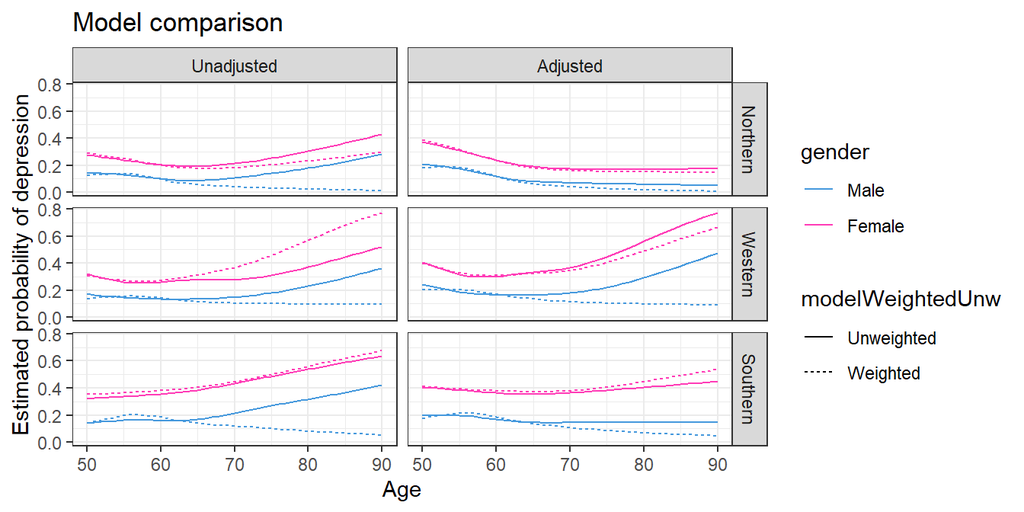

```r
ggplot(pred.age_all, aes(age1+50, fit, color=gender)) + geom_line(aes(linetype=modelWeightedUnw)) + facet_grid(region~modelAdjUnadj) + labs(x="Age", y="Estimated probability of depression") + scale_color_manual(values=c("#4699dd","#ff3db7" )) + ggtitle("Model comparison") +
 # geom_ribbon(aes(ymin = fit - 1.96*se.fit, ymax = fit + 1.96*se.fit), alpha = 0.2, linetype=0) +
  theme_bw()
```

```r
#to display all the coefficients
#get.OR2(my.mod1)

OR.w <- get.OR2(my.mod.w)[9:19,]

df <- cbind.data.frame(OR.uw, OR.w)

kable(df, digits=2, caption = "Estimated OR from the adjusted  unweighted (leftmost) and weighted (rightmost) rcs model")
```

Estimated OR from the adjusted unweighted (leftmost) and weighted (rightmost) rcs model

|  | OR | 95% CI LL | 95% CI UL | P-value | OR | 95% CI LL | 95% CI UL | P-value |
| --- | --- | --- | --- | --- | --- | --- | --- | --- |
| bmi_imp | 1.00 | 0.99 | 1.01 | 0.66 | 1.00 | 0.99 | 1.01 | 0.45 |
| education_impMedium | 0.75 | 0.69 | 0.80 | 0.00 | 0.72 | 0.65 | 0.80 | 0.00 |
| education_impHigh | 0.63 | 0.58 | 0.70 | 0.00 | 0.57 | 0.50 | 0.65 | 0.00 |
| education_impOther | 1.22 | 0.88 | 1.70 | 0.24 | 0.97 | 0.63 | 1.50 | 0.89 |
| dis_chronic_pres1 | 1.46 | 1.36 | 1.56 | 0.00 | 1.10 | 0.98 | 1.23 | 0.13 |
| dis_chronic_pres2+ | 2.44 | 2.23 | 2.66 | 0.00 | 1.50 | 1.36 | 1.65 | 0.00 |
| pa_vigOnce a week | 1.00 | 0.90 | 1.11 | 0.98 | 2.56 | 2.24 | 2.93 | 0.00 |
| pa_vigOne to three times a month | 1.10 | 0.98 | 1.24 | 0.10 | 1.01 | 0.87 | 1.17 | 0.90 |
| pa_vigHardly ever, or never | 1.78 | 1.65 | 1.92 | 0.00 | 1.24 | 1.05 | 1.45 | 0.01 |
| living_arrangementLiving alone | 1.49 | 1.39 | 1.59 | 0.00 | 1.78 | 1.59 | 1.99 | 0.00 |
| rcspline.eval(age_int_stand, knots = Knots, inclx = TRUE)x:regionWestern | 0.98 | 0.90 | 1.05 | 0.53 | 1.43 | 1.30 | 1.57 | 0.00 |

```r
#kable(get.OR2(my.mod1)[10:20,], digits=2, caption = "Estimated OR from the adjusted rcs model",     format = "latex")
```

Similar results were obtained removing a smaller number of influential observations (77 observations with weight above 25000, data not shown).

## 1.2 Analysis of the first interviews collected in the wave where the country was first included in the SHARE study

Here we limit the attention to the first interviews collected in the wave when the country was first included in the study. The analysis presented for data from Wave 1 can be easily extended for this problem.

First we subset the data, retrieve the weights for all waves and match the two datasets.

```r
share.data.w1 <- filter(share.data.first.interview,
                        ( is.element(country, c("Sweden", "Denmark", "Netherlands", "Belgium", "France", "Germany", "Austria", "Switzerland", "Spain", "Italy", "Greece")) & Wave=="Wave 1") |
                          ( is.element(country, c("Ireland", "Czech Republic", "Poland")) & Wave=="Wave 2")|
                          ( is.element(country, c("Portugal", "Hungary", "Slovenia", "Estonia")) & Wave=="Wave 4")|
                          ( is.element(country, c("Luxemburg")) & Wave=="Wave 5") |
                          ( is.element(country, c("Croatia")) & Wave=="Wave 6"))




# retrieval of weights for all waves
share.data.weights.all <- f_readRShare(
  datadir = "sharedata",
  waves = c(1,2,4,5,6),
  modules = c("gv_weights", "cv_r"),
  modules.wX = NULL  ,
  countries = NULL,
  variables.in.modules = list(gv_weights = NULL, cv_r = c("age_int", "gender", "yrbirth")),
  keep.module.name.in.vars = FALSE,
  verbose = FALSE
)$df.w


# initialization of the weights
share.data.w1$cciw_merged <- rep(-1, nrow(share.data.w1))


# Wave 1
which.obs <- which(is.element(share.data.w1$country, c("Sweden", "Denmark", "Netherlands", "Belgium", "France", "Germany", "Austria", "Switzerland", "Spain", "Italy", "Greece")) & share.data.w1$Wave=="Wave 1")
tmp <- left_join(share.data.w1[which.obs,], share.data.weights.all %>% filter(Wave == "Wave 1") %>% select(c("mergeid", "cciw_w1")), by="mergeid") %>% data.frame()
share.data.w1$cciw_merged[which.obs] <- tmp$cciw_w1


# Wave 2
which.obs <- which(is.element(share.data.w1$country, c("Ireland", "Czech Republic", "Poland")) & share.data.w1$Wave=="Wave 2")
tmp <- left_join(share.data.w1[which.obs,], share.data.weights.all %>% filter(Wave == "Wave 2") %>% select(c("mergeid", "cciw_w2")), by="mergeid") %>% data.frame()
share.data.w1$cciw_merged[which.obs] <- tmp$cciw_w2

# Wave 4
which.obs <- which(is.element(share.data.w1$country, c("Portugal", "Hungary", "Slovenia", "Estonia")) & share.data.w1$Wave=="Wave 4")
tmp <- left_join(share.data.w1[which.obs,], share.data.weights.all %>% filter(Wave == "Wave 4") %>% select(c("mergeid", "cciw_w4")), by="mergeid") %>% data.frame()
share.data.w1$cciw_merged[which.obs] <- tmp$cciw_w4


# Wave 5
which.obs <- which(is.element(share.data.w1$country, c("Luxemburg")) & share.data.w1$Wave=="Wave 5")
tmp <- left_join(share.data.w1[which.obs,], share.data.weights.all %>% filter(Wave == "Wave 5") %>% select(c("mergeid", "cciw_w5")), by="mergeid") %>% data.frame()
share.data.w1$cciw_merged[which.obs] <- tmp$cciw_w5

# Wave 6
which.obs <- which(is.element(share.data.w1$country, c("Croatia")) & share.data.w1$Wave=="Wave 6")
tmp <- left_join(share.data.w1[which.obs,], share.data.weights.all %>% filter(Wave == "Wave 6") %>% select(c("mergeid", "cciw_w6")), by="mergeid") %>% data.frame()
share.data.w1$cciw_merged[which.obs] <- tmp$cciw_w6



share.data.w1 <- filter(share.data.w1, !is.na(cciw_merged))

# retrieving psu and stratum1
share.data.w1 <- left_join(share.data.w1, share.data.weights.all[,c("mergeid", "Wave", "psu", "stratum1")], groupby = c("mergeid", "Wave"))


# setting to missing the strata and psu values that are empty
share.data.w1$stratum1[share.data.w1$stratum1==""] <- NA
share.data.w1$psu[share.data.w1$psu==""] <- NA

# number of missing psu
num.na.psu <- sum(is.na(share.data.w1$psu))
share.data.w1$psu <- as.numeric(share.data.w1$psu)

# using constant values for strata within country, all different values of psu for countries that did not have them in the design
share.data.w1$stratum1[is.na(share.data.w1$stratum1)] <- paste(share.data.w1$country[is.na(share.data.w1$stratum1)], "fake stratum")
share.data.w1$psu[is.na(share.data.w1$psu)] <- c((10^9+1) :  (10^9+num.na.psu))



# specify the sampling design
dstrat <- survey::svydesign(id=~psu,strata=~stratum1, weights=~ cciw_merged,
data = share.data.w1, nest=TRUE)

# id=∼psu specifies sampling at primary sampling unit.
# stratum1 is a factor variable for stratum used for sampling, usually geographical units
# share.data.w1 is the data frame with all the data.
# cciw_w1 contains calibrated sampling weights

# remove the participants not used in the analysis - removed because of missing data or exclusion criteria
dstrat <- subset(dstrat, !is.na(eurodcat_imp)) #& cciw_w1<=20000)
```

The analysis included 46358 participants. Using this selection stategy we included also participants from Eastern region.